# V2_p_9

```python
import pandas as pd
import numpy as np
import matplotlib as plt
import matplotlib.pyplot as plt
import seaborn as sns
from sklearn.linear_model import LinearRegression


import statsmodels.api as sm
import statsmodels.formula.api as smf
from scipy.stats import t, shapiro
from statsmodels.stats.outliers_influence import variance_inflation_factor
import statsmodels
```

les fichiers ont été transformés sous formats csv(valeurs separées par des vérgules) avant de les charger sur python

```python
cons_eng1= pd.read_csv("D:\\Aopenclassroom\\p9\\données/eCO2mix_RTE_energie.csv")
chauf= pd.read_csv("D:\\Aopenclassroom\\p9\\données/calcul_DJU_chaufage2.csv",index_col=[0])
clim= pd.read_csv("D:\\Aopenclassroom\\p9\\données/calcul_DJU_climatisation2.csv",index_col=[0])
```

```python
chauf
```

|  | JAN | FÉV | MAR | AVR | MAI | JUN | JUI | AOÛ | SEP | OCT | NOV | DÉC |
| --- | --- | --- | --- | --- | --- | --- | --- | --- | --- | --- | --- | --- |
| 2020 | 339.0 | 249.6 | 268.6 | 81.4 | 65.7 | 20.6 | 0.9 | 4.5 | 34.3 | 157.5 | 227.2 | 336.8 |
| 2019 | 404.9 | 268.3 | 233.1 | 168.5 | 117.9 | 24.4 | 0.0 | 1.7 | 26.7 | 133.7 | 282.6 | 327.3 |
| 2018 | 303.4 | 432.6 | 314.3 | 119.7 | 55.9 | 8.1 | 0.0 | 3.3 | 34.3 | 122.4 | 282.5 | 325.9 |
| 2017 | 467.9 | 278.4 | 206.1 | 182.6 | 75.0 | 9.4 | 1.0 | 6.8 | 62.6 | 99.4 | 282.6 | 369.0 |
| 2016 | 364.4 | 321.6 | 321.1 | 212.1 | 88.1 | 27.5 | 5.7 | 3.2 | 11.7 | 176.0 | 285.6 | 390.8 |
| 2015 | 392.0 | 365.7 | 275.5 | 141.1 | 91.5 | 15.8 | 6.9 | 6.1 | 71.9 | 176.9 | 195.0 | 248.1 |
| 2014 | 324.4 | 281.9 | 223.9 | 135.5 | 100.2 | 19.1 | 8.3 | 19.3 | 16.0 | 92.3 | 222.6 | 368.2 |
| 2013 | 429.2 | 402.2 | 376.6 | 209.5 | 158.4 | 43.6 | 0.6 | 5.0 | 41.5 | 105.0 | 303.9 | 349.5 |
| 2012 | 336.0 | 435.9 | 201.9 | 230.3 | 83.3 | 35.0 | 12.4 | 2.4 | 58.0 | 154.6 | 296.2 | 345.9 |
| 2011 | 392.0 | 304.8 | 243.1 | 77.6 | 43.4 | 31.4 | 15.0 | 11.9 | 23.2 | 127.6 | 226.6 | 312.7 |
| 2010 | 499.2 | 371.4 | 294.5 | 165.3 | 140.9 | 22.6 | 0.0 | 11.1 | 52.3 | 172.2 | 310.0 | 512.0 |
| 2009 | 486.8 | 365.7 | 293.2 | 135.1 | 82.2 | 39.8 | 3.1 | 0.9 | 26.9 | 149.6 | 224.7 | 411.8 |

```python
clim
```

|  | JAN | FÉV | MAR | AVR | MAI | JUN | JUI | AOÛ | SEP | OCT | NOV | DÉC |
| --- | --- | --- | --- | --- | --- | --- | --- | --- | --- | --- | --- | --- |
| 2020 | 0 | 0 | 0 | 11.5 | 28.6 | 57.5 | 96.6 | 157.0 | 72.3 | 0.0 | 0.0 | 0 |
| 2019 | 0 | 0 | 0 | 5.7 | 3.2 | 100.1 | 152.3 | 115.6 | 22.6 | 4.0 | 0.0 | 0 |
| 2018 | 0 | 0 | 0 | 16.1 | 42.9 | 74.6 | 198.7 | 126.3 | 33.2 | 17.0 | 0.0 | 0 |
| 2017 | 0 | 0 | 0 | 0.0 | 47.2 | 111.9 | 108.3 | 80.5 | 8.5 | 2.7 | 0.0 | 0 |
| 2016 | 0 | 0 | 0 | 0.0 | 8.5 | 37.0 | 105.6 | 121.4 | 59.1 | 0.0 | 0.0 | 0 |
| 2015 | 0 | 0 | 0 | 2.3 | 2.8 | 64.8 | 139.1 | 122.4 | 1.0 | 0.0 | 0.3 | 0 |
| 2014 | 0 | 0 | 0 | 0.0 | 2.2 | 41.3 | 101.1 | 35.7 | 45.8 | 7.1 | 0.0 | 0 |
| 2013 | 0 | 0 | 0 | 3.8 | 0.0 | 29.9 | 152.1 | 89.2 | 27.1 | 4.3 | 0.0 | 0 |
| 2012 | 0 | 0 | 0 | 0.0 | 30.1 | 25.6 | 60.4 | 117.9 | 20.4 | 1.4 | 0.0 | 0 |
| 2011 | 0 | 0 | 0 | 12.6 | 21.6 | 54.1 | 30.8 | 74.7 | 49.8 | 10.9 | 0.0 | 0 |
| 2010 | 0 | 0 | 0 | 3.3 | 16.1 | 64.3 | 134.7 | 59.2 | 8.0 | 4.3 | 0.0 | 0 |
| 2009 | 0 | 0 | 0 | 0.0 | 12.3 | 45.1 | 86.7 | 117.9 | 15.2 | 4.8 | 0.0 | 0 |

```python
cons_eng12= pd.read_csv("D:\\Aopenclassroom\\p9\\données/eCO2mix_RTE_Annuel-Definitif_2012.csv")#,parse_dates=['Date'])


cons_eng13= pd.read_csv("D:\\Aopenclassroom\\p9\\données/eCO2mix_RTE_Annuel-Definitif_2013.csv")#,parse_dates=['Date'])

cons_eng14= pd.read_csv("D:\\Aopenclassroom\\p9\\données/eCO2mix_RTE_Annuel-Definitif_2014.csv")#,parse_dates=['Date'])

cons_eng15= pd.read_csv("D:\\Aopenclassroom\\p9\\données/eCO2mix_RTE_Annuel-Definitif_2015.csv")#,parse_dates=['Date'])

cons_eng16= pd.read_csv("D:\\Aopenclassroom\\p9\\données/eCO2mix_RTE_Annuel-Definitif_2016.csv")#,parse_dates=['Date'])

cons_eng17= pd.read_csv("D:\\Aopenclassroom\\p9\\données/eCO2mix_RTE_Annuel-Definitif_2017.csv")#,parse_dates=['Date'])

cons_eng18= pd.read_csv("D:\\Aopenclassroom\\p9\\données/eCO2mix_RTE_Annuel-Definitif_2018.csv")#,parse_dates=['Date'])

cons_eng19= pd.read_csv("D:\\Aopenclassroom\\p9\\données/eCO2mix_RTE_Annuel-Definitif_2019.csv")#,parse_dates=['Date'])

cons_eng20= pd.read_csv("D:\\Aopenclassroom\\p9\\données/eCO2mix_RTE_Annuel-Definitif_2020.csv")#,parse_dates=['Date'])
```

```python
#SUPPRIMER LES DERNI2RES LIGNES DES DATAFRAMES
cons_eng12=cons_eng12.drop(cons_eng12.index[len(cons_eng12)-1])
cons_eng13=cons_eng13.drop(cons_eng13.index[len(cons_eng13)-1])
cons_eng14=cons_eng14.drop(cons_eng14.index[len(cons_eng14)-1])
cons_eng15=cons_eng15.drop(cons_eng15.index[len(cons_eng15)-1])
cons_eng16=cons_eng16.drop(cons_eng16.index[len(cons_eng16)-1])
cons_eng17=cons_eng17.drop(cons_eng17.index[len(cons_eng17)-1])
cons_eng18=cons_eng18.drop(cons_eng18.index[len(cons_eng18)-1])
cons_eng19=cons_eng19.drop(cons_eng19.index[len(cons_eng19)-1])
cons_eng20=cons_eng20.drop(cons_eng20.index[len(cons_eng20)-1])
```

# Données de la consommation en energie

```python
cons_eng1
```

|  | Mois | Qualité | Territoire | Production totale | Production nucléaire | Production thermique totale | Production thermique charbon | Production thermique fioul | Production thermique gaz | Production hydraulique | ... | Echanges avec le Royaume-Uni | Echanges avec l'Espagne | Echanges avec l'Italie | Echanges avec la Suisse | Echanges avec l'Allemagne et la Belgique | Pompage | Stockage batterie | Déstockage batterie | Eolien terrestre | Eolien offshore |
| --- | --- | --- | --- | --- | --- | --- | --- | --- | --- | --- | --- | --- | --- | --- | --- | --- | --- | --- | --- | --- | --- |
| 0 | 2010-01 | Données définitives | France | 56542.0 | 40313.0 | 8801.0 | 2928.0 | 1690.0 | 4184.0 | 6307.0 | ... | -652.0 | -358.0 | 1297.0 | 1613.0 | NaN | NaN | NaN | NaN | NaN | NaN |
| 1 | 2010-02 | Données définitives | France | 50406.0 | 36316.0 | 6822.0 | 1893.0 | 1175.0 | 3754.0 | 5887.0 | ... | -497.0 | -333.0 | 1628.0 | 1752.0 | NaN | NaN | NaN | NaN | NaN | NaN |
| 2 | 2010-03 | Données définitives | France | 51071.0 | 35984.0 | 7250.0 | 1994.0 | 1275.0 | 3981.0 | 6204.0 | ... | -365.0 | -360.0 | 1784.0 | 2022.0 | NaN | NaN | NaN | NaN | NaN | NaN |
| 3 | 2010-04 | Données définitives | France | 41693.0 | 31294.0 | 3568.0 | 1489.0 | 612.0 | 1467.0 | 5684.0 | ... | 67.0 | -337.0 | 1522.0 | 1900.0 | NaN | NaN | NaN | NaN | NaN | NaN |
| 4 | 2010-05 | Données définitives | France | 39847.0 | 29372.0 | 2843.0 | 1097.0 | 504.0 | 1242.0 | 6428.0 | ... | 486.0 | -147.0 | 1229.0 | 1287.0 | NaN | NaN | NaN | NaN | NaN | NaN |
| ... | ... | ... | ... | ... | ... | ... | ... | ... | ... | ... | ... | ... | ... | ... | ... | ... | ... | ... | ... | ... | ... |
| 1518 | 2021-11 | Données consolidées | Occitanie | 2142.0 | 897.0 | 59.0 | NaN | 0.0 | 59.0 | 638.0 | ... | NaN | NaN | NaN | NaN | NaN | NaN | NaN | NaN | NaN | NaN |
| 1519 | 2021-11 | Données consolidées | Normandie | 5376.0 | 4929.0 | 239.0 | -1.0 | 31.0 | 208.0 | 5.0 | ... | NaN | NaN | NaN | NaN | NaN | NaN | NaN | NaN | NaN | NaN |
| 1520 | 2021-11 | Données consolidées | Hauts-de-France | 4319.0 | 2265.0 | 1239.0 | 0.0 | 5.0 | 1233.0 | 1.0 | ... | NaN | NaN | NaN | NaN | NaN | NaN | NaN | NaN | NaN | NaN |
| 1521 | 2021-11 | Données consolidées | PACA | 1745.0 | NaN | 847.0 | -1.0 | 20.0 | 828.0 | 712.0 | ... | NaN | NaN | NaN | NaN | NaN | NaN | NaN | NaN | NaN | NaN |
| 1522 | 2021-11 | Données consolidées | Pays-de-la-Loire | 940.0 | NaN | 700.0 | 328.0 | 3.0 | 369.0 | 0.0 | ... | NaN | NaN | NaN | NaN | NaN | NaN | NaN | NaN | NaN | NaN |

1523 rows × 27 columns

```python
cons_eng1.describe()
```

|  | Production totale | Production nucléaire | Production thermique totale | Production thermique charbon | Production thermique fioul | Production thermique gaz | Production hydraulique | Production éolien | Production solaire | Production bioénergies | ... | Echanges avec le Royaume-Uni | Echanges avec l'Espagne | Echanges avec l'Italie | Echanges avec la Suisse | Echanges avec l'Allemagne et la Belgique | Pompage | Stockage batterie | Déstockage batterie | Eolien terrestre | Eolien offshore |
| --- | --- | --- | --- | --- | --- | --- | --- | --- | --- | --- | --- | --- | --- | --- | --- | --- | --- | --- | --- | --- | --- |
| count | 1487.000000 | 628.000000 | 1463.000000 | 473.000000 | 671.000000 | 671.000000 | 1175.000000 | 1055.000000 | 1391.000000 | 1463.000000 | ... | 107.000000 | 107.000000 | 107.000000 | 107.000000 | 109.000000 | 192.000000 | 0.0 | 0.0 | 0.0 | 0.0 |
| mean | 5347.397445 | 9227.007962 | 414.172932 | 280.704017 | 70.196721 | 487.727273 | 812.793191 | 336.559242 | 84.879942 | 82.372522 | ... | 429.859813 | 125.018692 | 849.906542 | 1049.299065 | 39.027523 | -131.031250 | NaN | NaN | NaN | NaN |
| std | 11492.077982 | 11096.125785 | 1045.724947 | 506.646972 | 181.455344 | 975.732292 | 1599.611315 | 647.428290 | 208.070573 | 161.776200 | ... | 898.152091 | 586.044254 | 1156.159653 | 954.915271 | 1287.575215 | 187.168958 | NaN | NaN | NaN | NaN |
| min | 0.000000 | 0.000000 | -4.000000 | -6.000000 | -4.000000 | -1.000000 | 0.000000 | 0.000000 | 0.000000 | -1.000000 | ... | -1453.000000 | -1217.000000 | -1704.000000 | -1314.000000 | -2912.000000 | -721.000000 | NaN | NaN | NaN | NaN |
| 25% | 48.000000 | 2856.500000 | 3.000000 | 0.000000 | 0.000000 | 17.500000 | 4.000000 | 37.500000 | 2.000000 | 9.000000 | ... | -300.000000 | -321.000000 | 777.000000 | 514.500000 | -838.000000 | -196.000000 | NaN | NaN | NaN | NaN |
| 50% | 556.000000 | 5237.000000 | 52.000000 | 60.000000 | 5.000000 | 118.000000 | 59.000000 | 122.000000 | 16.000000 | 36.000000 | ... | 583.000000 | 91.000000 | 1297.000000 | 1353.000000 | -48.000000 | -8.000000 | NaN | NaN | NaN | NaN |
| 75% | 5184.500000 | 7476.750000 | 334.500000 | 283.000000 | 41.000000 | 395.500000 | 750.000000 | 275.000000 | 68.500000 | 77.000000 | ... | 1133.500000 | 507.000000 | 1605.500000 | 1735.000000 | 859.000000 | -4.000000 | NaN | NaN | NaN | NaN |
| max | 58966.000000 | 43853.000000 | 8801.000000 | 2928.000000 | 1690.000000 | 5776.000000 | 8607.000000 | 5889.000000 | 1713.000000 | 892.000000 | ... | 1907.000000 | 1837.000000 | 2272.000000 | 2235.000000 | 2642.000000 | 0.000000 | NaN | NaN | NaN | NaN |

8 rows × 24 columns

```python
cons_eng1['Territoire'].unique()
```

```
array(['France', 'Grand-Est', 'Nouvelle-Aquitaine',
       'Auvergne-Rhône-Alpes', 'Bourgogne-Franche-Comté', 'Bretagne',
       'Centre-Val de Loire', 'Ile-de-France', 'Occitanie', 'Normandie',
       'Hauts-de-France', 'PACA', 'Pays-de-la-Loire', 'Aix Marseille',
       'Bordeaux', 'Brest', 'Clermont Ferrand', 'Dijon', 'Strasbourg',
       'Grenoble', 'Grand Lyon', 'Nancy', 'Grand Paris', 'Lille', 'Metz',
       'Montpellier', 'Rouen', 'Nantes', 'Nice', 'Orléans', 'Rennes',
       'Saint Etienne', 'Toulouse', 'Toulon', 'Tours'], dtype=object)
```

```python
c=cons_eng1.loc[cons_eng1['Territoire']=='Ile-de-France']
c['Consommation totale']
```

```
43         NaN
56         NaN
69         NaN
82         NaN
95         NaN
         ...
1465    4394.0
1478    4019.0
1491    4550.0
1504    5646.0
1517    6737.0
Name: Consommation totale, Length: 71, dtype: float64
```

```python
cons_eng2=cons_eng1.loc[(cons_eng1['Territoire'])=='France']
cons_eng2
```

|  | Mois | Qualité | Territoire | Production totale | Production nucléaire | Production thermique totale | Production thermique charbon | Production thermique fioul | Production thermique gaz | Production hydraulique | ... | Echanges avec le Royaume-Uni | Echanges avec l'Espagne | Echanges avec l'Italie | Echanges avec la Suisse | Echanges avec l'Allemagne et la Belgique | Pompage | Stockage batterie | Déstockage batterie | Eolien terrestre | Eolien offshore |
| --- | --- | --- | --- | --- | --- | --- | --- | --- | --- | --- | --- | --- | --- | --- | --- | --- | --- | --- | --- | --- | --- |
| 0 | 2010-01 | Données définitives | France | 56542.0 | 40313.0 | 8801.0 | 2928.0 | 1690.0 | 4184.0 | 6307.0 | ... | -652.0 | -358.0 | 1297.0 | 1613.0 | NaN | NaN | NaN | NaN | NaN | NaN |
| 1 | 2010-02 | Données définitives | France | 50406.0 | 36316.0 | 6822.0 | 1893.0 | 1175.0 | 3754.0 | 5887.0 | ... | -497.0 | -333.0 | 1628.0 | 1752.0 | NaN | NaN | NaN | NaN | NaN | NaN |
| 2 | 2010-03 | Données définitives | France | 51071.0 | 35984.0 | 7250.0 | 1994.0 | 1275.0 | 3981.0 | 6204.0 | ... | -365.0 | -360.0 | 1784.0 | 2022.0 | NaN | NaN | NaN | NaN | NaN | NaN |
| 3 | 2010-04 | Données définitives | France | 41693.0 | 31294.0 | 3568.0 | 1489.0 | 612.0 | 1467.0 | 5684.0 | ... | 67.0 | -337.0 | 1522.0 | 1900.0 | NaN | NaN | NaN | NaN | NaN | NaN |
| 4 | 2010-05 | Données définitives | France | 39847.0 | 29372.0 | 2843.0 | 1097.0 | 504.0 | 1242.0 | 6428.0 | ... | 486.0 | -147.0 | 1229.0 | 1287.0 | NaN | NaN | NaN | NaN | NaN | NaN |
| ... | ... | ... | ... | ... | ... | ... | ... | ... | ... | ... | ... | ... | ... | ... | ... | ... | ... | ... | ... | ... | ... |
| 1464 | 2021-07 | Données consolidées | France | 40555.0 | 28449.0 | 1605.0 | 54.0 | 159.0 | 1392.0 | 5626.0 | ... | 1907.0 | 1316.0 | 2090.0 | 1353.0 | NaN | NaN | NaN | NaN | NaN | NaN |
| 1477 | 2021-08 | Données consolidées | France | 39162.0 | 29010.0 | 957.0 | 70.0 | 166.0 | 720.0 | 4408.0 | ... | 1878.0 | 1837.0 | 2090.0 | 1393.0 | NaN | NaN | NaN | NaN | NaN | NaN |
| 1490 | 2021-09 | Données consolidées | France | 38505.0 | 29001.0 | 2197.0 | 498.0 | 146.0 | 1552.0 | 3417.0 | ... | 1114.0 | 1433.0 | 2126.0 | 1468.0 | NaN | NaN | NaN | NaN | NaN | NaN |
| 1503 | 2021-10 | Données consolidées | France | 41695.0 | 30658.0 | 3621.0 | 600.0 | 180.0 | 2840.0 | 3092.0 | ... | 464.0 | 861.0 | 2141.0 | 1873.0 | NaN | NaN | NaN | NaN | NaN | NaN |
| 1516 | 2021-11 | Données consolidées | France | 44284.0 | 30370.0 | 5726.0 | 566.0 | 192.0 | 4966.0 | 4026.0 | ... | -160.0 | -841.0 | 1045.0 | 1513.0 | NaN | NaN | NaN | NaN | NaN | NaN |

143 rows × 27 columns

```python
cons_eng2.Mois.unique()
```

```
array(['2010-01', '2010-02', '2010-03', '2010-04', '2010-05', '2010-06',
       '2010-07', '2010-08', '2010-09', '2010-10', '2010-11', '2010-12',
       '2011-01', '2011-02', '2011-03', '2011-04', '2011-05', '2011-06',
       '2011-07', '2011-08', '2011-09', '2011-10', '2011-11', '2011-12',
       '2012-01', '2012-02', '2012-03', '2012-04', '2012-05', '2012-06',
       '2012-07', '2012-08', '2012-09', '2012-10', '2012-11', '2012-12',
       '2013-01', '2013-02', '2013-03', '2013-04', '2013-05', '2013-06',
       '2013-07', '2013-08', '2013-09', '2013-10', '2013-11', '2013-12',
       '2014-01', '2014-02', '2014-03', '2014-04', '2014-05', '2014-06',
       '2014-07', '2014-08', '2014-09', '2014-10', '2014-11', '2014-12',
       '2015-01', '2015-02', '2015-03', '2015-04', '2015-05', '2015-06',
       '2015-07', '2015-08', '2015-09', '2015-10', '2015-11', '2015-12',
       '2016-01', '2016-02', '2016-03', '2016-04', '2016-05', '2016-06',
       '2016-07', '2016-08', '2016-09', '2016-10', '2016-11', '2016-12',
       '2017-01', '2017-02', '2017-03', '2017-04', '2017-05', '2017-06',
       '2017-07', '2017-08', '2017-09', '2017-10', '2017-11', '2017-12',
       '2018-01', '2018-02', '2018-03', '2018-04', '2018-05', '2018-06',
       '2018-07', '2018-08', '2018-09', '2018-10', '2018-11', '2018-12',
       '2019-01', '2019-02', '2019-03', '2019-04', '2019-05', '2019-06',
       '2019-07', '2019-08', '2019-09', '2019-10', '2019-11', '2019-12',
       '2020-01', '2020-02', '2020-03', '2020-04', '2020-05', '2020-06',
       '2020-07', '2020-08', '2020-09', '2020-10', '2020-11', '2020-12',
       '2021-01', '2021-02', '2021-03', '2021-04', '2021-05', '2021-06',
       '2021-07', '2021-08', '2021-09', '2021-10', '2021-11'],
      dtype=object)
```

```python
cons_eng3=cons_eng2[['Mois','Qualité','Consommation totale']]
```

```python
cons_eng3.describe()
```

|  | Consommation totale |
| --- | --- |
| count | 107.000000 |
| mean | 40676.785047 |
| std | 7175.689262 |
| min | 31004.000000 |
| 25% | 34217.000000 |
| 50% | 39170.000000 |
| 75% | 46234.500000 |
| max | 57600.000000 |

```python
cons_eng3.info()
```

```
<class 'pandas.core.frame.DataFrame'>
Int64Index: 143 entries, 0 to 1516
Data columns (total 3 columns):
 #   Column               Non-Null Count  Dtype
---  ------               --------------  -----
 0   Mois                 143 non-null    object
 1   Qualité              143 non-null    object
 2   Consommation totale  107 non-null    float64
dtypes: float64(1), object(2)
memory usage: 4.5+ KB
```

```python
cons_eng3.sort_values(by=['Consommation totale'],ascending=True)
#sort_values(by=['col1'])
```

|  | Mois | Qualité | Consommation totale |
| --- | --- | --- | --- |
| 289 | 2014-08 | Données définitives | 31004.0 |
| 1477 | 2021-08 | Données consolidées | 31184.0 |
| 133 | 2013-08 | Données définitives | 31591.0 |
| 445 | 2015-08 | Données définitives | 31603.0 |
| 1252 | 2020-09 | Données définitives | 31772.0 |
| ... | ... | ... | ... |
| 535 | 2018-08 | Données définitives | NaN |
| 536 | 2018-09 | Données définitives | NaN |
| 537 | 2018-10 | Données définitives | NaN |
| 538 | 2018-11 | Données définitives | NaN |
| 539 | 2018-12 | Données définitives | NaN |

143 rows × 3 columns

```python
cons_eng3.isna().sum()
```

```
Mois                    0
Qualité                 0
Consommation totale    36
dtype: int64
```

```python
#les données manquantes concernent celles des 3 ans 2016,2017,2018"on les chargent année par années
na=cons_eng3.loc[cons_eng3['Consommation totale'].isna()==True]
```

## compléter les données manquantes

```python
cons_eng=pd.concat([cons_eng12,cons_eng13,cons_eng14,cons_eng15,cons_eng16,cons_eng17,cons_eng18,cons_eng19,cons_eng20], ignore_index=True)
cons_eng.head()
```

|  | Périmètre | Nature | Date | Heures | Consommation | Prévision J-1 | Prévision J | Fioul | Charbon | Gaz | ... | Hydraulique - Fil de l?eau + éclusée | Hydraulique - Lacs | Hydraulique - STEP turbinage | Bioénergies - Déchets | Bioénergies - Biomasse | Bioénergies - Biogaz | Stockage batterie | Déstockage batterie | Eolien terrestre | Eolien offshore |
| --- | --- | --- | --- | --- | --- | --- | --- | --- | --- | --- | --- | --- | --- | --- | --- | --- | --- | --- | --- | --- | --- |
| 0 | France | Données définitives | 2012-01-01 | 00:00 | 58315.0 | 58200.0 | 58200.0 | 492.0 | 25.0 | 3816.0 | ... | ND | ND | ND | ND | ND | ND | NaN | NaN | NaN | NaN |
| 1 | France | Données définitives | 2012-01-01 | 00:15 | NaN | 57700.0 | 57550.0 | NaN | NaN | NaN | ... | NaN | NaN | NaN | NaN | NaN | NaN | NaN | NaN | NaN | NaN |
| 2 | France | Données définitives | 2012-01-01 | 00:30 | 58315.0 | 57200.0 | 56900.0 | 492.0 | 25.0 | 3816.0 | ... | ND | ND | ND | ND | ND | ND | NaN | NaN | NaN | NaN |
| 3 | France | Données définitives | 2012-01-01 | 00:45 | NaN | 56200.0 | 56000.0 | NaN | NaN | NaN | ... | NaN | NaN | NaN | NaN | NaN | NaN | NaN | NaN | NaN | NaN |
| 4 | France | Données définitives | 2012-01-01 | 01:00 | 56231.0 | 55200.0 | 55100.0 | 492.0 | 25.0 | 3834.0 | ... | ND | ND | ND | ND | ND | ND | NaN | NaN | NaN | NaN |

5 rows × 40 columns

```python
#cons_eng=pd.concat([cons_eng16,cons_eng17,cons_eng18], ignore_index=True)
#cons_eng
```

```python
cons_eng.Périmètre.unique()
```

```
array(['France'], dtype=object)
```

```python
cons_eng=cons_eng.loc[cons_eng.Périmètre=='France']
```

```python
nan1=cons_eng.loc[cons_eng['Consommation'].isna()==True]
nan1
```

|  | Périmètre | Nature | Date | Heures | Consommation | Prévision J-1 | Prévision J | Fioul | Charbon | Gaz | ... | Hydraulique - Fil de l?eau + éclusée | Hydraulique - Lacs | Hydraulique - STEP turbinage | Bioénergies - Déchets | Bioénergies - Biomasse | Bioénergies - Biogaz | Stockage batterie | Déstockage batterie | Eolien terrestre | Eolien offshore |
| --- | --- | --- | --- | --- | --- | --- | --- | --- | --- | --- | --- | --- | --- | --- | --- | --- | --- | --- | --- | --- | --- |
| 1 | France | Données définitives | 2012-01-01 | 00:15 | NaN | 57700.0 | 57550.0 | NaN | NaN | NaN | ... | NaN | NaN | NaN | NaN | NaN | NaN | NaN | NaN | NaN | NaN |
| 3 | France | Données définitives | 2012-01-01 | 00:45 | NaN | 56200.0 | 56000.0 | NaN | NaN | NaN | ... | NaN | NaN | NaN | NaN | NaN | NaN | NaN | NaN | NaN | NaN |
| 5 | France | Données définitives | 2012-01-01 | 01:15 | NaN | 55600.0 | 55250.0 | NaN | NaN | NaN | ... | NaN | NaN | NaN | NaN | NaN | NaN | NaN | NaN | NaN | NaN |
| 7 | France | Données définitives | 2012-01-01 | 01:45 | NaN | 56000.0 | 55200.0 | NaN | NaN | NaN | ... | NaN | NaN | NaN | NaN | NaN | NaN | NaN | NaN | NaN | NaN |
| 9 | France | Données définitives | 2012-01-01 | 02:15 | NaN | 55750.0 | 54300.0 | NaN | NaN | NaN | ... | NaN | NaN | NaN | NaN | NaN | NaN | NaN | NaN | NaN | NaN |
| ... | ... | ... | ... | ... | ... | ... | ... | ... | ... | ... | ... | ... | ... | ... | ... | ... | ... | ... | ... | ... | ... |
| 315639 | France | Données définitives | 2020-12-31 | 21:45 | NaN | 64100.0 | 63450.0 | NaN | NaN | NaN | ... | NaN | NaN | NaN | NaN | NaN | NaN | ND | ND | NaN | NaN |
| 315641 | France | Données définitives | 2020-12-31 | 22:15 | NaN | 64800.0 | 64200.0 | NaN | NaN | NaN | ... | NaN | NaN | NaN | NaN | NaN | NaN | ND | ND | NaN | NaN |
| 315643 | France | Données définitives | 2020-12-31 | 22:45 | NaN | 66650.0 | 66100.0 | NaN | NaN | NaN | ... | NaN | NaN | NaN | NaN | NaN | NaN | ND | ND | NaN | NaN |
| 315645 | France | Données définitives | 2020-12-31 | 23:15 | NaN | 67550.0 | 67100.0 | NaN | NaN | NaN | ... | NaN | NaN | NaN | NaN | NaN | NaN | ND | ND | NaN | NaN |
| 315647 | France | Données définitives | 2020-12-31 | 23:45 | NaN | 67300.0 | 67100.0 | NaN | NaN | NaN | ... | NaN | NaN | NaN | NaN | NaN | NaN | ND | ND | NaN | NaN |

157824 rows × 40 columns

```python
cons_eng=cons_eng[['Date','Nature','Consommation']]
cons_eng
```

|  | Date | Nature | Consommation |
| --- | --- | --- | --- |
| 0 | 2012-01-01 | Données définitives | 58315.0 |
| 1 | 2012-01-01 | Données définitives | NaN |
| 2 | 2012-01-01 | Données définitives | 58315.0 |
| 3 | 2012-01-01 | Données définitives | NaN |
| 4 | 2012-01-01 | Données définitives | 56231.0 |
| ... | ... | ... | ... |
| 315643 | 2020-12-31 | Données définitives | NaN |
| 315644 | 2020-12-31 | Données définitives | 66853.0 |
| 315645 | 2020-12-31 | Données définitives | NaN |
| 315646 | 2020-12-31 | Données définitives | 66750.0 |
| 315647 | 2020-12-31 | Données définitives | NaN |

315648 rows × 3 columns

```python
cons_eng.isna().sum()
```

```
Date                 0
Nature               0
Consommation    157824
dtype: int64
```

```python
nan=cons_eng.loc[cons_eng['Consommation'].isna()==True]
nan
```

|  | Date | Nature | Consommation |
| --- | --- | --- | --- |
| 1 | 2012-01-01 | Données définitives | NaN |
| 3 | 2012-01-01 | Données définitives | NaN |
| 5 | 2012-01-01 | Données définitives | NaN |
| 7 | 2012-01-01 | Données définitives | NaN |
| 9 | 2012-01-01 | Données définitives | NaN |
| ... | ... | ... | ... |
| 315639 | 2020-12-31 | Données définitives | NaN |
| 315641 | 2020-12-31 | Données définitives | NaN |
| 315643 | 2020-12-31 | Données définitives | NaN |
| 315645 | 2020-12-31 | Données définitives | NaN |
| 315647 | 2020-12-31 | Données définitives | NaN |

157824 rows × 3 columns

```python
nan.Date.unique()
```

```
array(['2012-01-01', '2012-01-02', '2012-01-03', ..., '2020-12-29',
       '2020-12-30', '2020-12-31'], dtype=object)
```

```python
cons_eng['Date']=pd.to_datetime(cons_eng['Date'])
cons_eng
```

|  | Date | Nature | Consommation |
| --- | --- | --- | --- |
| 0 | 2012-01-01 | Données définitives | 58315.0 |
| 1 | 2012-01-01 | Données définitives | NaN |
| 2 | 2012-01-01 | Données définitives | 58315.0 |
| 3 | 2012-01-01 | Données définitives | NaN |
| 4 | 2012-01-01 | Données définitives | 56231.0 |
| ... | ... | ... | ... |
| 315643 | 2020-12-31 | Données définitives | NaN |
| 315644 | 2020-12-31 | Données définitives | 66853.0 |
| 315645 | 2020-12-31 | Données définitives | NaN |
| 315646 | 2020-12-31 | Données définitives | 66750.0 |
| 315647 | 2020-12-31 | Données définitives | NaN |

315648 rows × 3 columns

```python
#cons_gb=cons_eng.groupby(pd.Grouper(key='Date', axis=0,
                      #freq='M')).mean().reset_index()#['Consommation'].agg('mean').reset_index()
#cons_gb
```

```python
cons_eng_gb=pd.DataFrame(cons_eng.groupby(cons_eng['Date'].dt.strftime(('%Y-%m')))['Consommation'].mean()).sort_values(by='Date',ascending=False).reset_index()
cons_eng_gb
```

|  | Date | Consommation |
| --- | --- | --- |
| 0 | 2020-12 | 63700.449597 |
| 1 | 2020-11 | 55049.665972 |
| 2 | 2020-10 | 51213.493952 |
| 3 | 2020-09 | 44599.290972 |
| 4 | 2020-08 | 41920.820565 |
| ... | ... | ... |
| 103 | 2012-05 | 47095.206317 |
| 104 | 2012-04 | 55485.681944 |
| 105 | 2012-03 | 57722.497984 |
| 106 | 2012-02 | 77847.751437 |
| 107 | 2012-01 | 68261.475806 |

108 rows × 2 columns

# Données chaufage

```python
chauf
```

|  | JAN | FÉV | MAR | AVR | MAI | JUN | JUI | AOÛ | SEP | OCT | NOV | DÉC |
| --- | --- | --- | --- | --- | --- | --- | --- | --- | --- | --- | --- | --- |
| 2020 | 339.0 | 249.6 | 268.6 | 81.4 | 65.7 | 20.6 | 0.9 | 4.5 | 34.3 | 157.5 | 227.2 | 336.8 |
| 2019 | 404.9 | 268.3 | 233.1 | 168.5 | 117.9 | 24.4 | 0.0 | 1.7 | 26.7 | 133.7 | 282.6 | 327.3 |
| 2018 | 303.4 | 432.6 | 314.3 | 119.7 | 55.9 | 8.1 | 0.0 | 3.3 | 34.3 | 122.4 | 282.5 | 325.9 |
| 2017 | 467.9 | 278.4 | 206.1 | 182.6 | 75.0 | 9.4 | 1.0 | 6.8 | 62.6 | 99.4 | 282.6 | 369.0 |
| 2016 | 364.4 | 321.6 | 321.1 | 212.1 | 88.1 | 27.5 | 5.7 | 3.2 | 11.7 | 176.0 | 285.6 | 390.8 |
| 2015 | 392.0 | 365.7 | 275.5 | 141.1 | 91.5 | 15.8 | 6.9 | 6.1 | 71.9 | 176.9 | 195.0 | 248.1 |
| 2014 | 324.4 | 281.9 | 223.9 | 135.5 | 100.2 | 19.1 | 8.3 | 19.3 | 16.0 | 92.3 | 222.6 | 368.2 |
| 2013 | 429.2 | 402.2 | 376.6 | 209.5 | 158.4 | 43.6 | 0.6 | 5.0 | 41.5 | 105.0 | 303.9 | 349.5 |
| 2012 | 336.0 | 435.9 | 201.9 | 230.3 | 83.3 | 35.0 | 12.4 | 2.4 | 58.0 | 154.6 | 296.2 | 345.9 |
| 2011 | 392.0 | 304.8 | 243.1 | 77.6 | 43.4 | 31.4 | 15.0 | 11.9 | 23.2 | 127.6 | 226.6 | 312.7 |
| 2010 | 499.2 | 371.4 | 294.5 | 165.3 | 140.9 | 22.6 | 0.0 | 11.1 | 52.3 | 172.2 | 310.0 | 512.0 |
| 2009 | 486.8 | 365.7 | 293.2 | 135.1 | 82.2 | 39.8 | 3.1 | 0.9 | 26.9 | 149.6 | 224.7 | 411.8 |

```python
#on s'arete à mai 2021
```

```python
ch=chauf.rename(columns={"JAN": "01",
                      "FÉV":"02",
                      "MAR":"03",
                      "AVR":"04",
                      "MAI":"05",
                      "JUN":"06",
                      "JUI":"07",
                      "AOÛ":"08",
                      "SEP":"09",
                      "OCT":"10",
                      "NOV":"11",
                      "DÉC":"12"})
```

```python
#ch=ch.drop(columns=['Total'])
```

```python
ch
```

|  | 01 | 02 | 03 | 04 | 05 | 06 | 07 | 08 | 09 | 10 | 11 | 12 |
| --- | --- | --- | --- | --- | --- | --- | --- | --- | --- | --- | --- | --- |
| 2020 | 339.0 | 249.6 | 268.6 | 81.4 | 65.7 | 20.6 | 0.9 | 4.5 | 34.3 | 157.5 | 227.2 | 336.8 |
| 2019 | 404.9 | 268.3 | 233.1 | 168.5 | 117.9 | 24.4 | 0.0 | 1.7 | 26.7 | 133.7 | 282.6 | 327.3 |
| 2018 | 303.4 | 432.6 | 314.3 | 119.7 | 55.9 | 8.1 | 0.0 | 3.3 | 34.3 | 122.4 | 282.5 | 325.9 |
| 2017 | 467.9 | 278.4 | 206.1 | 182.6 | 75.0 | 9.4 | 1.0 | 6.8 | 62.6 | 99.4 | 282.6 | 369.0 |
| 2016 | 364.4 | 321.6 | 321.1 | 212.1 | 88.1 | 27.5 | 5.7 | 3.2 | 11.7 | 176.0 | 285.6 | 390.8 |
| 2015 | 392.0 | 365.7 | 275.5 | 141.1 | 91.5 | 15.8 | 6.9 | 6.1 | 71.9 | 176.9 | 195.0 | 248.1 |
| 2014 | 324.4 | 281.9 | 223.9 | 135.5 | 100.2 | 19.1 | 8.3 | 19.3 | 16.0 | 92.3 | 222.6 | 368.2 |
| 2013 | 429.2 | 402.2 | 376.6 | 209.5 | 158.4 | 43.6 | 0.6 | 5.0 | 41.5 | 105.0 | 303.9 | 349.5 |
| 2012 | 336.0 | 435.9 | 201.9 | 230.3 | 83.3 | 35.0 | 12.4 | 2.4 | 58.0 | 154.6 | 296.2 | 345.9 |
| 2011 | 392.0 | 304.8 | 243.1 | 77.6 | 43.4 | 31.4 | 15.0 | 11.9 | 23.2 | 127.6 | 226.6 | 312.7 |
| 2010 | 499.2 | 371.4 | 294.5 | 165.3 | 140.9 | 22.6 | 0.0 | 11.1 | 52.3 | 172.2 | 310.0 | 512.0 |
| 2009 | 486.8 | 365.7 | 293.2 | 135.1 | 82.2 | 39.8 | 3.1 | 0.9 | 26.9 | 149.6 | 224.7 | 411.8 |

```python
# transformer la matrice en dataframe
l_ch={'mois':[],'chaufage':[]}

for année in ch.index.values:
    for mois in ch.columns:

            l_ch['mois'].append(f"{année}-{mois}")
            l_ch['chaufage'].append(ch.loc[année,mois])

            df_ch= pd.DataFrame(l_ch)
```

```python
df_ch
```

|  | mois | chaufage |
| --- | --- | --- |
| 0 | 2020-01 | 339.0 |
| 1 | 2020-02 | 249.6 |
| 2 | 2020-03 | 268.6 |
| 3 | 2020-04 | 81.4 |
| 4 | 2020-05 | 65.7 |
| ... | ... | ... |
| 139 | 2009-08 | 0.9 |
| 140 | 2009-09 | 26.9 |
| 141 | 2009-10 | 149.6 |
| 142 | 2009-11 | 224.7 |
| 143 | 2009-12 | 411.8 |

144 rows × 2 columns

```python
df_ch.chaufage.dtype
```

```
dtype('float64')
```

# Données sur la climatisation

```python
clim
```

|  | JAN | FÉV | MAR | AVR | MAI | JUN | JUI | AOÛ | SEP | OCT | NOV | DÉC |
| --- | --- | --- | --- | --- | --- | --- | --- | --- | --- | --- | --- | --- |
| 2020 | 0 | 0 | 0 | 11.5 | 28.6 | 57.5 | 96.6 | 157.0 | 72.3 | 0.0 | 0.0 | 0 |
| 2019 | 0 | 0 | 0 | 5.7 | 3.2 | 100.1 | 152.3 | 115.6 | 22.6 | 4.0 | 0.0 | 0 |
| 2018 | 0 | 0 | 0 | 16.1 | 42.9 | 74.6 | 198.7 | 126.3 | 33.2 | 17.0 | 0.0 | 0 |
| 2017 | 0 | 0 | 0 | 0.0 | 47.2 | 111.9 | 108.3 | 80.5 | 8.5 | 2.7 | 0.0 | 0 |
| 2016 | 0 | 0 | 0 | 0.0 | 8.5 | 37.0 | 105.6 | 121.4 | 59.1 | 0.0 | 0.0 | 0 |
| 2015 | 0 | 0 | 0 | 2.3 | 2.8 | 64.8 | 139.1 | 122.4 | 1.0 | 0.0 | 0.3 | 0 |
| 2014 | 0 | 0 | 0 | 0.0 | 2.2 | 41.3 | 101.1 | 35.7 | 45.8 | 7.1 | 0.0 | 0 |
| 2013 | 0 | 0 | 0 | 3.8 | 0.0 | 29.9 | 152.1 | 89.2 | 27.1 | 4.3 | 0.0 | 0 |
| 2012 | 0 | 0 | 0 | 0.0 | 30.1 | 25.6 | 60.4 | 117.9 | 20.4 | 1.4 | 0.0 | 0 |
| 2011 | 0 | 0 | 0 | 12.6 | 21.6 | 54.1 | 30.8 | 74.7 | 49.8 | 10.9 | 0.0 | 0 |
| 2010 | 0 | 0 | 0 | 3.3 | 16.1 | 64.3 | 134.7 | 59.2 | 8.0 | 4.3 | 0.0 | 0 |
| 2009 | 0 | 0 | 0 | 0.0 | 12.3 | 45.1 | 86.7 | 117.9 | 15.2 | 4.8 | 0.0 | 0 |

```python
clm=clim.rename(columns={"JAN": "01",
                      "FÉV":"02",
                      "MAR":"03",
                      "AVR":"04",
                      "MAI":"05",
                      "JUN":"06",
                      "JUI":"07",
                      "AOÛ":"08",
                      "SEP":"09",
                      "OCT":"10",
                      "NOV":"11",
                      "DÉC":"12"})
clm
```

|  | 01 | 02 | 03 | 04 | 05 | 06 | 07 | 08 | 09 | 10 | 11 | 12 |
| --- | --- | --- | --- | --- | --- | --- | --- | --- | --- | --- | --- | --- |
| 2020 | 0 | 0 | 0 | 11.5 | 28.6 | 57.5 | 96.6 | 157.0 | 72.3 | 0.0 | 0.0 | 0 |
| 2019 | 0 | 0 | 0 | 5.7 | 3.2 | 100.1 | 152.3 | 115.6 | 22.6 | 4.0 | 0.0 | 0 |
| 2018 | 0 | 0 | 0 | 16.1 | 42.9 | 74.6 | 198.7 | 126.3 | 33.2 | 17.0 | 0.0 | 0 |
| 2017 | 0 | 0 | 0 | 0.0 | 47.2 | 111.9 | 108.3 | 80.5 | 8.5 | 2.7 | 0.0 | 0 |
| 2016 | 0 | 0 | 0 | 0.0 | 8.5 | 37.0 | 105.6 | 121.4 | 59.1 | 0.0 | 0.0 | 0 |
| 2015 | 0 | 0 | 0 | 2.3 | 2.8 | 64.8 | 139.1 | 122.4 | 1.0 | 0.0 | 0.3 | 0 |
| 2014 | 0 | 0 | 0 | 0.0 | 2.2 | 41.3 | 101.1 | 35.7 | 45.8 | 7.1 | 0.0 | 0 |
| 2013 | 0 | 0 | 0 | 3.8 | 0.0 | 29.9 | 152.1 | 89.2 | 27.1 | 4.3 | 0.0 | 0 |
| 2012 | 0 | 0 | 0 | 0.0 | 30.1 | 25.6 | 60.4 | 117.9 | 20.4 | 1.4 | 0.0 | 0 |
| 2011 | 0 | 0 | 0 | 12.6 | 21.6 | 54.1 | 30.8 | 74.7 | 49.8 | 10.9 | 0.0 | 0 |
| 2010 | 0 | 0 | 0 | 3.3 | 16.1 | 64.3 | 134.7 | 59.2 | 8.0 | 4.3 | 0.0 | 0 |
| 2009 | 0 | 0 | 0 | 0.0 | 12.3 | 45.1 | 86.7 | 117.9 | 15.2 | 4.8 | 0.0 | 0 |

```python
# transformer la matrice en dataframe
l_clm={'mois':[],'climatisation':[]}

for année in clm.index.values:
    for mois in clm.columns:

            l_clm['mois'].append(f"{année}-{mois}")
            l_clm['climatisation'].append(clm.loc[année,mois])

            df_clm= pd.DataFrame(l_clm)
```

```python
 df_clm
```

|  | mois | climatisation |
| --- | --- | --- |
| 0 | 2020-01 | 0.0 |
| 1 | 2020-02 | 0.0 |
| 2 | 2020-03 | 0.0 |
| 3 | 2020-04 | 11.5 |
| 4 | 2020-05 | 28.6 |
| ... | ... | ... |
| 139 | 2009-08 | 117.9 |
| 140 | 2009-09 | 15.2 |
| 141 | 2009-10 | 4.8 |
| 142 | 2009-11 | 0.0 |
| 143 | 2009-12 | 0.0 |

144 rows × 2 columns

### assembler les dataframes

```python
#renir les trois dataframe ("consomation en energie, DJU consomation en energie et climatisation") faire le merge
dju=df_ch.merge(df_clm,how='inner')
```

```python
dju.chaufage.dtype
```

```
dtype('float64')
```

```python
dju.climatisation.dtype
```

```
dtype('float64')
```

```python
#dju['mois']=pd.to_datetime(dju['mois'])
```

```python
cons_eng_ren=cons_eng_gb.rename(columns={"Date": "mois"})
cons_eng_ren
```

|  | mois | Consommation |
| --- | --- | --- |
| 0 | 2020-12 | 63700.449597 |
| 1 | 2020-11 | 55049.665972 |
| 2 | 2020-10 | 51213.493952 |
| 3 | 2020-09 | 44599.290972 |
| 4 | 2020-08 | 41920.820565 |
| ... | ... | ... |
| 103 | 2012-05 | 47095.206317 |
| 104 | 2012-04 | 55485.681944 |
| 105 | 2012-03 | 57722.497984 |
| 106 | 2012-02 | 77847.751437 |
| 107 | 2012-01 | 68261.475806 |

108 rows × 2 columns

```python
cons_eng_ren.Consommation.dtype
```

```
dtype('float64')
```

```python
elec=cons_eng_ren.merge(dju,how='inner').sort_values(by='mois',ascending=True)
elec
```

|  | mois | Consommation | chaufage | climatisation |
| --- | --- | --- | --- | --- |
| 107 | 2012-01 | 68261.475806 | 336.0 | 0.0 |
| 106 | 2012-02 | 77847.751437 | 435.9 | 0.0 |
| 105 | 2012-03 | 57722.497984 | 201.9 | 0.0 |
| 104 | 2012-04 | 55485.681944 | 230.3 | 0.0 |
| 103 | 2012-05 | 47095.206317 | 83.3 | 30.1 |
| ... | ... | ... | ... | ... |
| 4 | 2020-08 | 41920.820565 | 4.5 | 157.0 |
| 3 | 2020-09 | 44599.290972 | 34.3 | 72.3 |
| 2 | 2020-10 | 51213.493952 | 157.5 | 0.0 |
| 1 | 2020-11 | 55049.665972 | 227.2 | 0.0 |
| 0 | 2020-12 | 63700.449597 | 336.8 | 0.0 |

108 rows × 4 columns

```python
#mettre la colonne en dateTime
elec['mois']=pd.to_datetime(elec['mois'])
elec
```

|  | mois | Consommation | chaufage | climatisation |
| --- | --- | --- | --- | --- |
| 107 | 2012-01-01 | 68261.475806 | 336.0 | 0.0 |
| 106 | 2012-02-01 | 77847.751437 | 435.9 | 0.0 |
| 105 | 2012-03-01 | 57722.497984 | 201.9 | 0.0 |
| 104 | 2012-04-01 | 55485.681944 | 230.3 | 0.0 |
| 103 | 2012-05-01 | 47095.206317 | 83.3 | 30.1 |
| ... | ... | ... | ... | ... |
| 4 | 2020-08-01 | 41920.820565 | 4.5 | 157.0 |
| 3 | 2020-09-01 | 44599.290972 | 34.3 | 72.3 |
| 2 | 2020-10-01 | 51213.493952 | 157.5 | 0.0 |
| 1 | 2020-11-01 | 55049.665972 | 227.2 | 0.0 |
| 0 | 2020-12-01 | 63700.449597 | 336.8 | 0.0 |

108 rows × 4 columns

```python
elec.isna().sum()
```

```
mois             0
Consommation     0
chaufage         0
climatisation    0
dtype: int64
```

```python
elec.isnull().sum()
```

```
mois             0
Consommation     0
chaufage         0
climatisation    0
dtype: int64
```

```python
elec.Consommation.dtype
```

```
dtype('float64')
```

```python
elec.describe()
```

|  | Consommation | chaufage | climatisation |
| --- | --- | --- | --- |
| count | 108.000000 | 108.000000 | 108.000000 |
| mean | 54132.216668 | 170.752778 | 29.209259 |
| std | 9968.028955 | 140.657776 | 46.664282 |
| min | 40959.981855 | 0.000000 | 0.000000 |
| 25% | 45781.610764 | 27.300000 | 0.000000 |
| 50% | 50770.691667 | 156.050000 | 1.200000 |
| 75% | 62891.967910 | 288.250000 | 41.700000 |
| max | 77847.751437 | 467.900000 | 198.700000 |

les données sont propres ne contennent pas de données manquantes ni aberantes

# ploter les données

## consommation en electricité

```python
e=elec.copy()
```

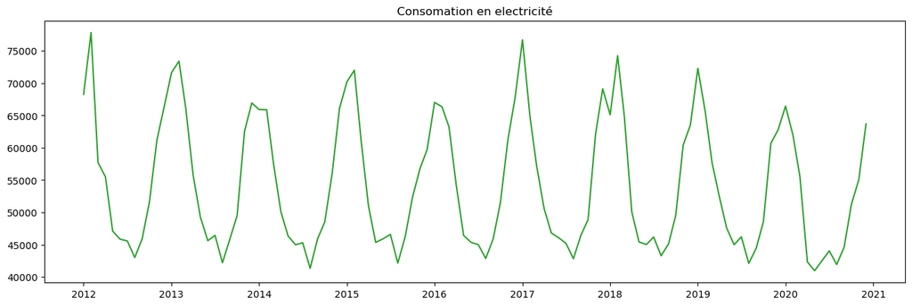

```python
# Draw Plot
def plot_df(df,x, y, title="", xlabel='', ylabel='', dpi=100):
    plt.figure(figsize=(16,5), dpi=dpi)
    plt.plot(x, y, color='tab:green')
    plt.gca().set(title=title, xlabel=xlabel, ylabel=ylabel)
    plt.show()
plt.savefig('p9_figures/Consommation en energie supperposées.jpg')
plot_df(elec, x=elec.mois, y=elec['Consommation'], title='Consomation en electricité')
```

on est sur un model aditif les pics et les creux forment deux droites paralléles

## Tracé saisonnier consommation en electricité

[figure not shown]

```python
# Prepare data
e['year'] = [d.strftime('%Y') for d in e.mois]
e['month'] = [d.strftime('%b') for d in e.mois]
years = e['year'].unique()
# Prep Colors
#np.random.seed(100)
#mycolors = np.random.choice(list(plt.colors.XKCD_COLORS.keys()), len(years), replace=False)

# Draw Plot
plt.figure(figsize=(16,12), dpi= 80)
for i, y in enumerate(years):
    if i > 0:
        plt.plot('month', 'Consommation', data=e.loc[e.year==y, :]) #color=mycolors[i],label=y)
        plt.text(e.loc[e.year==y, :].shape[0]-.9, e.loc[e.year==y, 'Consommation'][-1:].values[0], y, fontsize=12)#, color=mycolors[i])

# Decoration
#plt.gca().set(xlim=(-0.3, 11), ylim=(2, 30), ylabel='$Drug Sales$', xlabel='$Month$')
plt.yticks(fontsize=12, alpha=.7)
plt.title("Consommation en électricité", fontsize=20)
plt.legend(years)
plt.savefig('p9_figures/Consommation en energie supperposées.jpg')
plt.show()
```

# Besoin en chafage et climatisation

```python
el=elec[['mois','chaufage','climatisation']].set_index('mois')
```

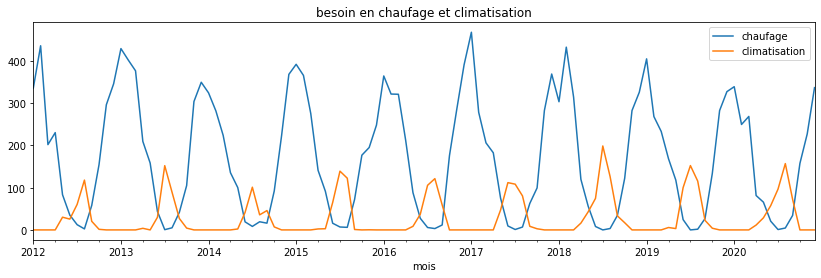

```python
    el['chaufage'].plot(figsize=(14,4),label="chaufage")
    el['climatisation'].plot(figsize=(14,4),label="climatisation")
    plt.title('besoin en chaufage et climatisation')
    plt.legend()

    plt.savefig('p9_figures/Consommation en energie supperposées.jpg')
```

## besoin en chaufage electrique

## Tracé saisonnier besoin en chaufage

[figure not shown]

```python
# Prepare data
e['year'] = [d.strftime('%Y') for d in e.mois]
e['month'] = [d.strftime('%b') for d in e.mois]
years = e['year'].unique()
# Prep Colors
#np.random.seed(100)
#mycolors = np.random.choice(list(plt.colors.XKCD_COLORS.keys()), len(years), replace=False)

# Draw Plot
plt.figure(figsize=(12,7), dpi= 80)
for i, y in enumerate(years):
    if i > 0:
        plt.plot('month', 'chaufage', data=e.loc[e.year==y, :]) #color=mycolors[i],label=y)
        plt.text(e.loc[e.year==y, :].shape[0]-.9, e.loc[e.year==y, 'chaufage'][-1:].values[0], y, fontsize=12)#, color=mycolors[i])

# Decoration
#plt.gca().set(xlim=(-0.3, 11), ylim=(2, 30), ylabel='$Drug Sales$', xlabel='$Month$')
plt.yticks(fontsize=12, alpha=.7)
plt.title("besoin saisonier en chauffage ", fontsize=20)
plt.legend(years)
plt.savefig('p9_figures/Consommation en energie supperposées.jpg')
plt.show()
```

## besoin en electricité pour la climatisation

### Tracé saisonnier besoin en climatisation

[figure not shown]

```python
# Prepare data
e['year'] = [d.strftime('%Y') for d in e.mois]
e['month'] = [d.strftime('%b') for d in e.mois]
years = e['year'].unique()
# Prep Colors
#np.random.seed(100)
#mycolors = np.random.choice(list(plt.colors.XKCD_COLORS.keys()), len(years), replace=False)

# Draw Plot
plt.figure(figsize=(12,10), dpi= 80)
for i, y in enumerate(years):
    if i > 0:
        plt.plot('month', 'climatisation', data=e.loc[e.year==y, :]) #color=mycolors[i],label=y)
        plt.text(e.loc[e.year==y, :].shape[0]-.9, e.loc[e.year==y, 'climatisation'][-1:].values[0], y, fontsize=12)#, color=mycolors[i])

# Decoration
plt.gca().set( ylabel='$besoin en climatisation$', xlabel='$Month$')
plt.yticks(fontsize=12, alpha=.7)
plt.title("Besoin saisonnier en climatisation", fontsize=20)
plt.legend(years)
plt.savefig('p9_figures/Consommation en energie supperposées.jpg')
plt.show()
```

```python
elec['dju']=elec['chaufage']+elec['climatisation']

elec
```

|  | mois | Consommation | chaufage | climatisation | dju |
| --- | --- | --- | --- | --- | --- |
| 107 | 2012-01-01 | 68261.475806 | 336.0 | 0.0 | 336.0 |
| 106 | 2012-02-01 | 77847.751437 | 435.9 | 0.0 | 435.9 |
| 105 | 2012-03-01 | 57722.497984 | 201.9 | 0.0 | 201.9 |
| 104 | 2012-04-01 | 55485.681944 | 230.3 | 0.0 | 230.3 |
| 103 | 2012-05-01 | 47095.206317 | 83.3 | 30.1 | 113.4 |
| ... | ... | ... | ... | ... | ... |
| 4 | 2020-08-01 | 41920.820565 | 4.5 | 157.0 | 161.5 |
| 3 | 2020-09-01 | 44599.290972 | 34.3 | 72.3 | 106.6 |
| 2 | 2020-10-01 | 51213.493952 | 157.5 | 0.0 | 157.5 |
| 1 | 2020-11-01 | 55049.665972 | 227.2 | 0.0 | 227.2 |
| 0 | 2020-12-01 | 63700.449597 | 336.8 | 0.0 | 336.8 |

108 rows × 5 columns

```python
e_ind=elec.set_index('mois')
e_ind
```

| mois | Consommation | chaufage | climatisation | dju |
| --- | --- | --- | --- | --- |
| 2012-01-01 | 68261.475806 | 336.0 | 0.0 | 336.0 |
| 2012-02-01 | 77847.751437 | 435.9 | 0.0 | 435.9 |
| 2012-03-01 | 57722.497984 | 201.9 | 0.0 | 201.9 |
| 2012-04-01 | 55485.681944 | 230.3 | 0.0 | 230.3 |
| 2012-05-01 | 47095.206317 | 83.3 | 30.1 | 113.4 |
| ... | ... | ... | ... | ... |
| 2020-08-01 | 41920.820565 | 4.5 | 157.0 | 161.5 |
| 2020-09-01 | 44599.290972 | 34.3 | 72.3 | 106.6 |
| 2020-10-01 | 51213.493952 | 157.5 | 0.0 | 157.5 |
| 2020-11-01 | 55049.665972 | 227.2 | 0.0 | 227.2 |
| 2020-12-01 | 63700.449597 | 336.8 | 0.0 | 336.8 |

108 rows × 4 columns

```python
elc=e_ind[['Consommation','chaufage','climatisation']]
elc
```

| mois | Consommation | chaufage | climatisation |
| --- | --- | --- | --- |
| 2012-01-01 | 68261.475806 | 336.0 | 0.0 |
| 2012-02-01 | 77847.751437 | 435.9 | 0.0 |
| 2012-03-01 | 57722.497984 | 201.9 | 0.0 |
| 2012-04-01 | 55485.681944 | 230.3 | 0.0 |
| 2012-05-01 | 47095.206317 | 83.3 | 30.1 |
| ... | ... | ... | ... |
| 2020-08-01 | 41920.820565 | 4.5 | 157.0 |
| 2020-09-01 | 44599.290972 | 34.3 | 72.3 |
| 2020-10-01 | 51213.493952 | 157.5 | 0.0 |
| 2020-11-01 | 55049.665972 | 227.2 | 0.0 |
| 2020-12-01 | 63700.449597 | 336.8 | 0.0 |

108 rows × 3 columns

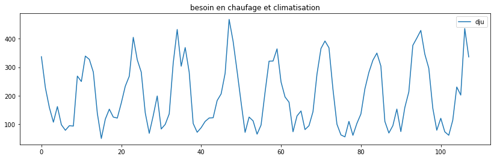

```python
elec['dju'].plot(figsize=(14,4),label="dju")
#elec['Consommation'].plot(figsize=(14,4),label="Consommation")
plt.title('besoin en chaufage et climatisation')
plt.legend()
plt.savefig('p9_figures/Consommation en energie supperposées.jpg')
```

# Correction des données de consommation mensuelles de l'effet température:

(dues au chauffage électrique) en utilisant une régression linéaire.

```python
Une série temporelle Yt est communément décomposée en tendance, saisonnalité, bruit:

Yt=Tt+St+εt

la tendance Tt correspondant à une évolution à long terme de la série, par exemple:

tendance linéaire: Tt=a+bt
tendance quadratique: Tt=a+bt+ct2
tendance logarithmique: Tt=log(t)
```

[output not shown]

## regression linéaire

```python
electr=elc.copy()
```

```python
reg_e = smf.ols('Consommation~chaufage+climatisation', data=electr).fit()
print(reg_e.summary())
```

```
                            OLS Regression Results
==============================================================================
Dep. Variable:           Consommation   R-squared:                       0.961
Model:                            OLS   Adj. R-squared:                  0.961
Method:                 Least Squares   F-statistic:                     1305.
Date:                Tue, 05 Jul 2022   Prob (F-statistic):           6.88e-75
Time:                        10:47:43   Log-Likelihood:                -971.47
No. Observations:                 108   AIC:                             1949.
Df Residuals:                     105   BIC:                             1957.
Df Model:                           2
Covariance Type:            nonrobust
=================================================================================
                    coef    std err          t      P>|t|      [0.025      0.975]
---------------------------------------------------------------------------------
Intercept      4.001e+04    495.621     80.733      0.000     3.9e+04     4.1e+04
chaufage         76.8834      1.901     40.437      0.000      73.113      80.653
climatisation    33.9385      5.731      5.922      0.000      22.575      45.302
==============================================================================
Omnibus:                        0.222   Durbin-Watson:                   1.749
Prob(Omnibus):                  0.895   Jarque-Bera (JB):                0.082
Skew:                          -0.066   Prob(JB):                        0.960
Kurtosis:                       3.024   Cond. No.                         575.
==============================================================================

Notes:
[1] Standard Errors assume that the covariance matrix of the errors is correctly specified.
```

```python
reg_e.params
```

```
Intercept        40012.845574
chaufage            76.883395
climatisation       33.938478
dtype: float64
```

```python
b1=reg_e.params[1]
c1=reg_e.params[2]
b1,c1
```

```
(76.88339520318864, 33.93847782995306)
```

```python
electr['Consommation_corg1'] = electr['Consommation'] - (electr['chaufage']*b1)-(electr['climatisation']*c1)
electr
```

| mois | Consommation | chaufage | climatisation | Consommation_corg1 |
| --- | --- | --- | --- | --- |
| 2012-01-01 | 68261.475806 | 336.0 | 0.0 | 42428.655018 |
| 2012-02-01 | 77847.751437 | 435.9 | 0.0 | 44334.279468 |
| 2012-03-01 | 57722.497984 | 201.9 | 0.0 | 42199.740492 |
| 2012-04-01 | 55485.681944 | 230.3 | 0.0 | 37779.436029 |
| 2012-05-01 | 47095.206317 | 83.3 | 30.1 | 39669.271314 |
| ... | ... | ... | ... | ... |
| 2020-08-01 | 41920.820565 | 4.5 | 157.0 | 36246.504267 |
| 2020-09-01 | 44599.290972 | 34.3 | 72.3 | 39508.438570 |
| 2020-10-01 | 51213.493952 | 157.5 | 0.0 | 39104.359207 |
| 2020-11-01 | 55049.665972 | 227.2 | 0.0 | 37581.758582 |
| 2020-12-01 | 63700.449597 | 336.8 | 0.0 | 37806.122092 |

108 rows × 4 columns

```python
data_cor1=electr[['Consommation','Consommation_corg1']]
data_cor1
```

| mois | Consommation | Consommation_corg1 |
| --- | --- | --- |
| 2012-01-01 | 68261.475806 | 42428.655018 |
| 2012-02-01 | 77847.751437 | 44334.279468 |
| 2012-03-01 | 57722.497984 | 42199.740492 |
| 2012-04-01 | 55485.681944 | 37779.436029 |
| 2012-05-01 | 47095.206317 | 39669.271314 |
| ... | ... | ... |
| 2020-08-01 | 41920.820565 | 36246.504267 |
| 2020-09-01 | 44599.290972 | 39508.438570 |
| 2020-10-01 | 51213.493952 | 39104.359207 |
| 2020-11-01 | 55049.665972 | 37581.758582 |
| 2020-12-01 | 63700.449597 | 37806.122092 |

108 rows × 2 columns

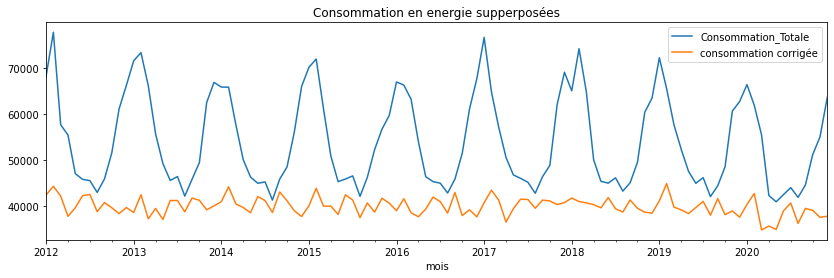

```python
electr['Consommation'].plot(figsize=(14,4),label="Consommation_Totale")
electr['Consommation_corg1'].plot(label='consommation corrigée')

plt.title('Consommation en energie supperposées')
plt.legend()
plt.savefig('p9_figures/Consommation en energie supperposées.jpg')
```

## Verifier la colinearité des variables

```python
variables = reg_e.model.exog
[variance_inflation_factor(variables, i) for i in np.arange(1,variables.shape[1])]
```

```
[1.95445692253576, 1.95445692253576]
```

les coeficients sont inferieurs à 10 les variables ne sont pas correlées entre elles

## tester l'homocidacité

```python
#calcule des residues
electr['rstudent'] = reg_e.get_influence().resid_studentized_internal
```

```python
#tester l’homoscédasticité (c'est-à-dire la constance de la variance) des résidus
_, pval, __, f_pval = statsmodels.stats.diagnostic.het_breuschpagan(reg_e.resid, variables)
print('p value test Breusch Pagan:', pval)
```

```
p value test Breusch Pagan: 0.5772346011834666
```

La p-value est supérieure à 5%, nous ne pouvons pas rejeter l’hypothèse H0 selon laquelle les variances sont constantes .

## tester la normalite des residues

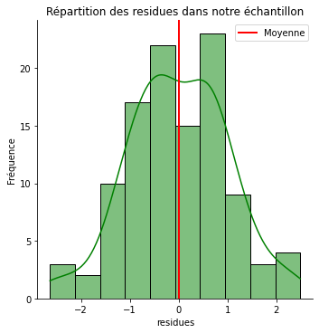

```python
sns.displot(data=electr, x="rstudent", kde=True ,color='green')

plt.axvline(x=electr["rstudent"].mean(), label='Moyenne', linestyle='-', linewidth=2, color='red')
#plt.axvline(x=electr["rstudent"].median(), label='Médiane', linestyle='--', linewidth=2 ,color='red')
plt.xlabel('residues')
plt.ylabel('Fréquence')
plt.title('Répartition des residues dans notre échantillon')
#plt.ylim(0,20)
plt.legend()


plt.savefig('p9_figures/Distribution_rstudent_regression.jpg')

plt.show()
```

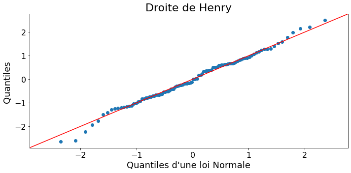

```python
#diagrame QQ

import statsmodels.api as smi
import pylab

X = reg_e.resid
# Droite de Henry
fig, ax = plt.subplots(figsize=(10, 5))

sm.qqplot(X, line='45', fit=True, ax=ax)

plt.ylabel('Quantiles ', fontsize=18)
plt.yticks(fontsize=16)
plt.xlabel('Quantiles d\'une loi Normale',fontsize=18)
plt.xticks(fontsize=16)
plt.title('Droite de Henry', fontsize=22)

plt.tight_layout()


plt.savefig('p9_figures/qqplot_histo_residus_reg.jpg')
plt.show()
```

La on remarque une distribution des residues symetrique alignée avec la distribution théorique d'une loi normale. Un test de Shapiro-Wilk est nécessaire pour confirmer.

### test Shapiro_Wilk

```python
#le nombre de données est<5000 , on fait le test d'adequation à une loie normale  avec le testshapiro wilk
from scipy.stats import t, shapiro, ks_2samp
shapiro(reg_e.resid)
```

```
ShapiroResult(statistic=0.9925020337104797, pvalue=0.8224667310714722)
```

la p value etant de 0.8 >5% On peut pas rejeter l'hypothese H0 donc les residues suivent une loi normale ils sont centres autour de 0 ecart type=1

# vérsion logarithme

```python
electr['log_consommation']=np.log(electr['Consommation'])
```

```python
reg_elc_log = smf.ols('log_consommation~chaufage+climatisation', data=electr).fit()
print(reg_elc_log.summary())
```

```
                            OLS Regression Results
==============================================================================
Dep. Variable:       log_consommation   R-squared:                       0.960
Model:                            OLS   Adj. R-squared:                  0.959
Method:                 Least Squares   F-statistic:                     1268.
Date:                Tue, 05 Jul 2022   Prob (F-statistic):           2.99e-74
Time:                        10:48:14   Log-Likelihood:                 207.16
No. Observations:                 108   AIC:                            -408.3
Df Residuals:                     105   BIC:                            -400.3
Df Model:                           2
Covariance Type:            nonrobust
=================================================================================
                    coef    std err          t      P>|t|      [0.025      0.975]
---------------------------------------------------------------------------------
Intercept        10.6403      0.009   1178.546      0.000      10.622      10.658
chaufage          0.0013   3.46e-05     38.851      0.000       0.001       0.001
climatisation     0.0004      0.000      4.240      0.000       0.000       0.001
==============================================================================
Omnibus:                        5.929   Durbin-Watson:                   1.792
Prob(Omnibus):                  0.052   Jarque-Bera (JB):                5.560
Skew:                          -0.428   Prob(JB):                       0.0620
Kurtosis:                       3.709   Cond. No.                         575.
==============================================================================

Notes:
[1] Standard Errors assume that the covariance matrix of the errors is correctly specified.
```

ici on remarqie que le R² a diminué ce qui nous laisse suposer que le premier model sans log est plus performant on effectue des testes sur le premier model

[figure not shown]

```python
sns.displot(data=electr, x="log_consommation", kde=True ,color='green')

plt.axvline(x=electr["log_consommation"].mean(), label='Moyenne', linestyle='-', linewidth=2, color='red')
plt.xlabel('residues')
plt.ylabel('Fréquence')
plt.title('Répartition des residues dans notre échantillon')
#plt.ylim(0,20)
plt.legend()


plt.savefig('p9_figures/Distribution_rstudent_regression_log.jpg')

plt.show()
```

on a le R² proche de 1 . la p_value <5% donc le resultat est significative donc la valeur dju influe sur la Consommation en electricité

# Effectuez une déssaisonnalisation de la consommation que vous aurez obtenue après correction, grâce aux moyennes mobiles

on utilise cet methode pour resortir la tendance Xt=Tt+St+εt Si on applique une moyenne mobile M sur la série, nous obtenons (grâce à la propriété d'associativité) : MXt=MTt+MSt+Mεt . tq: MTt=Tt MSt=0 Mεt =>faible

```python
ser_corrig1=data_cor1.copy()
ser_corrig1
```

| mois | Consommation | Consommation_corg1 |
| --- | --- | --- |
| 2012-01-01 | 68261.475806 | 42428.655018 |
| 2012-02-01 | 77847.751437 | 44334.279468 |
| 2012-03-01 | 57722.497984 | 42199.740492 |
| 2012-04-01 | 55485.681944 | 37779.436029 |
| 2012-05-01 | 47095.206317 | 39669.271314 |
| ... | ... | ... |
| 2020-08-01 | 41920.820565 | 36246.504267 |
| 2020-09-01 | 44599.290972 | 39508.438570 |
| 2020-10-01 | 51213.493952 | 39104.359207 |
| 2020-11-01 | 55049.665972 | 37581.758582 |
| 2020-12-01 | 63700.449597 | 37806.122092 |

108 rows × 2 columns

```python
ser_corrig=ser_corrig1[['Consommation_corg1']]
ser_corrig
```

| mois | Consommation_corg1 |
| --- | --- |
| 2012-01-01 | 42428.655018 |
| 2012-02-01 | 44334.279468 |
| 2012-03-01 | 42199.740492 |
| 2012-04-01 | 37779.436029 |
| 2012-05-01 | 39669.271314 |
| ... | ... |
| 2020-08-01 | 36246.504267 |
| 2020-09-01 | 39508.438570 |
| 2020-10-01 | 39104.359207 |
| 2020-11-01 | 37581.758582 |
| 2020-12-01 | 37806.122092 |

108 rows × 1 columns

La méthode seasonal_decompose de statsmodels permet de visualiser la tendance, la saisonnalité et le résidu du signal.

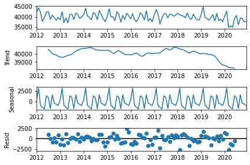

```python
from statsmodels.tsa.seasonal import seasonal_decompose

decomp_x = seasonal_decompose(ser_corrig,  model='additive')
decomp_x.plot()

plt.savefig('p9_figures/Décomposition de la consommation en energie.jpg')
plt.show()
```

```python
# Time Series Decomposition
result_mul = seasonal_decompose(ser_corrig['Consommation_corg1'], model='additive', extrapolate_trend='freq')

# Deseasonalize
deseasonal = ser_corrig['Consommation_corg1'].values - result_mul.seasonal

deseasonal
```

```
mois
2012-01-01    42015.795134
2012-02-01    41282.543698
2012-03-01    42854.827499
2012-04-01    39381.663164
2012-05-01    41386.567323
                  ...
2020-08-01    37938.878863
2020-09-01    37990.910451
2020-10-01    39347.662840
2020-11-01    38173.633015
2020-12-01    38632.157253
Name: seasonal, Length: 108, dtype: float64
```

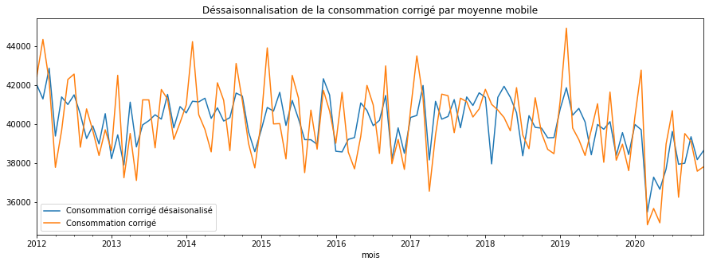

```python
# Plot
deseasonal.plot(figsize=(15,3),label="Consommation corrigé désaisonalisé")

ser_corrig['Consommation_corg1'].plot(figsize=(15,5),label="Consommation corrigé")

plt.title('Déssaisonnalisation de la consommation corrigé par moyenne mobile')
plt.legend()
plt.savefig('p9_figures/Consommation en energiecorrigé et déssaisonalisée superposées  supperposées.jpg')
```

```python
ser_corrig
```

| mois | Consommation_corg1 |
| --- | --- |
| 2012-01-01 | 42428.655018 |
| 2012-02-01 | 44334.279468 |
| 2012-03-01 | 42199.740492 |
| 2012-04-01 | 37779.436029 |
| 2012-05-01 | 39669.271314 |
| ... | ... |
| 2020-08-01 | 36246.504267 |
| 2020-09-01 | 39508.438570 |
| 2020-10-01 | 39104.359207 |
| 2020-11-01 | 37581.758582 |
| 2020-12-01 | 37806.122092 |

108 rows × 1 columns

Le signal ressort corrigé et désaisonnalisé, il est de plus en plus représentatif d'un modèle additif.

# Effectuez une prévision de la consommation:

(corrigée de l'effet température) sur un an, en utilisant la méthode de Holt Winters (lissage exponentiel) puis la méthode SARIMA sur la série temporelle.

## méthode de Holt Winters:

Ajustement des données avec le lissage exponentiel de Holt-Winters

```python
# holt winters
# single exponential smoothing
from statsmodels.tsa.holtwinters import SimpleExpSmoothing
# double and triple exponential smoothing
from statsmodels.tsa.holtwinters import ExponentialSmoothing
```

```python
# Set the frequency of the date time index as Monthly start as indicated by the data
ser_corrig.index.freq = 'MS'
# Set the value of Alpha and define m (Time Period)
m = 12
alpha = 1/(2*m)
alpha
```

```
0.041666666666666664
```

# Maintenant, nous allons ajuster les données sur le lissage exponentiel simple

### Single HWES

```python
ser_corrig
```

| mois | Consommation_corg1 |
| --- | --- |
| 2012-01-01 | 42428.655018 |
| 2012-02-01 | 44334.279468 |
| 2012-03-01 | 42199.740492 |
| 2012-04-01 | 37779.436029 |
| 2012-05-01 | 39669.271314 |
| ... | ... |
| 2020-08-01 | 36246.504267 |
| 2020-09-01 | 39508.438570 |
| 2020-10-01 | 39104.359207 |
| 2020-11-01 | 37581.758582 |
| 2020-12-01 | 37806.122092 |

108 rows × 1 columns

```python
ser_hwe=ser_corrig.copy()
```

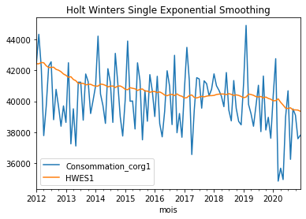

```python
ser_hwe['HWES1'] = SimpleExpSmoothing(ser_hwe['Consommation_corg1']).fit(smoothing_level=alpha,optimized=False,use_brute=True).fittedvalues
ser_hwe[['Consommation_corg1','HWES1']].plot(title='Holt Winters Single Exponential Smoothing')
plt.savefig('p9_figures/Consommation en energie supperposées.jpg')
```

sa ne fonction pas car le data a une sesonalité et un trend

### Triple HWES:aditif

```python
import warnings
from statsmodels.tools.sm_exceptions import ConvergenceWarning
warnings.simplefilter('ignore', ConvergenceWarning)
```

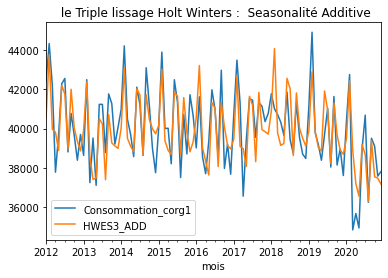

```python
ser_hwe['HWES3_ADD'] = ExponentialSmoothing(ser_hwe['Consommation_corg1'],trend='add',seasonal='add',seasonal_periods=12).fit().fittedvalues
ser_hwe[['Consommation_corg1','HWES3_ADD']].plot(title=' le Triple lissage Holt Winters :  Seasonalité Additive')
plt.savefig('p9_figures/Consommation en energie et saisonalité supperposées.jpg')
```

## prevision

```python
ser_hwe
```

| mois | Consommation_corg1 | HWES1 | HWES3_ADD |
| --- | --- | --- | --- |
| 2012-01-01 | 42428.655018 | 42428.655018 | 40581.781181 |
| 2012-02-01 | 44334.279468 | 42428.655018 | 43767.767147 |
| 2012-03-01 | 42199.740492 | 42508.056037 | 39966.447132 |
| 2012-04-01 | 37779.436029 | 42495.209556 | 39818.222250 |
| 2012-05-01 | 39669.271314 | 42298.718992 | 38882.714103 |
| ... | ... | ... | ... |
| 2020-08-01 | 36246.504267 | 39582.429874 | 36295.524192 |
| 2020-09-01 | 39508.438570 | 39443.432973 | 39381.468203 |
| 2020-10-01 | 39104.359207 | 39446.141540 | 37543.955486 |
| 2020-11-01 | 37581.758582 | 39431.900609 | 37479.104783 |
| 2020-12-01 | 37806.122092 | 39354.811358 | 37178.231305 |

108 rows × 3 columns

```python
#preparer les donner diviser le data en deux partiestest et train

cons_train =ser_hwe.iloc[:-24,:-2]

cons_test=ser_hwe.iloc[-24:-12,:-2]
```

```python
cons_train
```

| mois | Consommation_corg1 |
| --- | --- |
| 2012-01-01 | 42428.655018 |
| 2012-02-01 | 44334.279468 |
| 2012-03-01 | 42199.740492 |
| 2012-04-01 | 37779.436029 |
| 2012-05-01 | 39669.271314 |
| ... | ... |
| 2018-08-01 | 38734.207196 |
| 2018-09-01 | 41344.083053 |
| 2018-10-01 | 39546.174218 |
| 2018-11-01 | 38700.500577 |
| 2018-12-01 | 38478.891691 |

84 rows × 1 columns

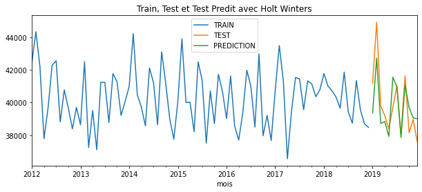

```python
fitted_model =ExponentialSmoothing(cons_train['Consommation_corg1'],trend='add',seasonal='add',seasonal_periods=12).fit()
test_predictions = fitted_model.forecast(12)
cons_train['Consommation_corg1'].plot(legend=True,label='TRAIN')
cons_test['Consommation_corg1'].plot(legend=True,label='TEST',figsize=(10,4))
test_predictions.plot(legend=True,label='PREDICTION')
plt.title('Train, Test et Test Predit avec Holt Winters')
plt.savefig('p9_figures/prevision_holt_winters_test_supperposées.jpg')
```

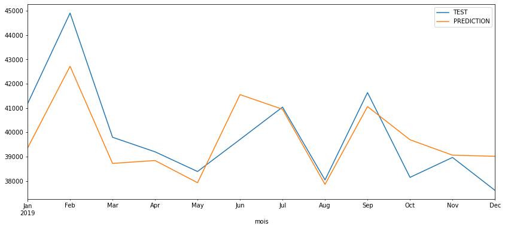

```python
cons_test['Consommation_corg1'].plot(legend=True,label='TEST',figsize=(14,6))
test_predictions.plot(legend=True,label='PREDICTION');
plt.savefig('p9_figures/comparaison_prevision_holt_winters_test_supperposées.jpg')
```

### évaluation Métriques

Voyons comment le modèle s'est comporté en termes de calculs des termes d'erreur. Nous utiliserions MAE (Mean Absolute Error) et MSE (Mean Squared Error) comme mesures.

```python
from sklearn.metrics import mean_absolute_error,mean_squared_error
print(f'Mean Absolute Error = {mean_absolute_error(cons_test,test_predictions)}')
print(f'Mean Squared Error = {mean_squared_error(cons_test,test_predictions)}')
```

```
Mean Absolute Error = 970.7395250858875
Mean Squared Error = 1481834.3263622115
```

# Effectuez une prévision de la consommation (corrigée de l'effet température) sur un an, en utilisant la méthode SARIMA sur la série temporelle.

```python
cons_s=ser_corrig.copy()
cons_s
```

| mois | Consommation_corg1 |
| --- | --- |
| 2012-01-01 | 42428.655018 |
| 2012-02-01 | 44334.279468 |
| 2012-03-01 | 42199.740492 |
| 2012-04-01 | 37779.436029 |
| 2012-05-01 | 39669.271314 |
| ... | ... |
| 2020-08-01 | 36246.504267 |
| 2020-09-01 | 39508.438570 |
| 2020-10-01 | 39104.359207 |
| 2020-11-01 | 37581.758582 |
| 2020-12-01 | 37806.122092 |

108 rows × 1 columns

dans un premier temps, nous allons tester la stationnarité de notre série avec le test ADF (Augmented Dickey-Fuller). L'hypothèse nulle du test est que la série temporelle n'est pas stationnaire.

```python
from statsmodels.tsa.stattools import adfuller, acf, pacf
```

```python
y_len = len(cons_s['Consommation_corg1'])
y_len
```

```
108
```

```python
from statsmodels.tsa.stattools import adfuller, acf, pacf

#ADF-test(Série originelle)
adf_o = adfuller(cons_s['Consommation_corg1'],regression='ct')
print('p-value ADF série originelle :{}'.format(adf_o[1]))

#ADF-test(Série différenciée)
adf_d = adfuller(cons_s['Consommation_corg1'].diff().dropna(),regression='ct')
print('p-value ADF série différenciée :{}'.format(adf_d[1]))
```

```
p-value ADF série originelle :0.27031869816536236
p-value ADF série différenciée :0.005027668770853414
```

Au niveau de test 5%, on ne rejette pas l'hypothèse de non-stationnarité de la série, contrairement à la série différenciée.

### stationnarisation.

Nous allons réaliser cette stationnarisation par différenciation de manière itérative si besoin

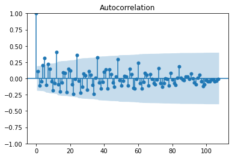

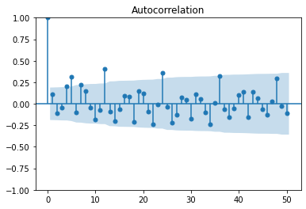

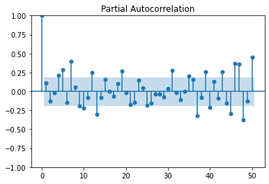

```python
from statsmodels.graphics.tsaplots import plot_acf,plot_pacf

plot_acf(cons_s, lags=107)
plot_acf(cons_s, lags=50)
plot_pacf(cons_s, lags=50)
plt.savefig('p9_figures/Corelograme_d-autocorelation_simple_et_partiel_avant_difference1.jpg')
#plt.show()
```

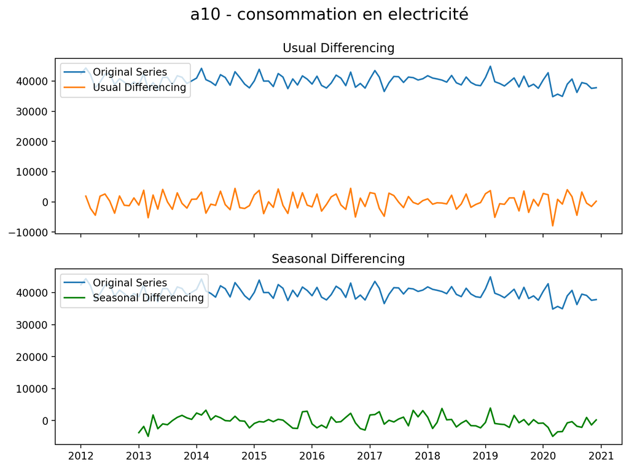

```python
# Plot
fig, axes = plt.subplots(2, 1, figsize=(10,7), dpi=200, sharex=True)

# Usual Differencing
axes[0].plot(cons_s[:], label='Original Series')
axes[0].plot(cons_s[:].diff(1), label='Usual Differencing')
axes[0].set_title('Usual Differencing')
axes[0].legend(loc='upper left', fontsize=10)


# Seasinal Dei
axes[1].plot(cons_s[:], label='Original Series')
axes[1].plot(cons_s[:].diff(12), label='Seasonal Differencing', color='green')
axes[1].set_title('Seasonal Differencing')
plt.legend(loc='upper left', fontsize=10)
plt.suptitle('a10 - consommation en electricité', fontsize=16)
plt.savefig('p9_figures/variation de la Consommation en energie avant et apres differenciation.jpg')
plt.show()
```

```python
#on differencie par ordre 1 pour eliminer les tendances stockastiques
y_dif1= cons_s.diff(1)
y_dif1
```

| mois | Consommation_corg1 |
| --- | --- |
| 2012-01-01 | NaN |
| 2012-02-01 | 1905.624450 |
| 2012-03-01 | -2134.538975 |
| 2012-04-01 | -4420.304463 |
| 2012-05-01 | 1889.835285 |
| ... | ... |
| 2020-08-01 | -4436.339687 |
| 2020-09-01 | 3261.934303 |
| 2020-10-01 | -404.079363 |
| 2020-11-01 | -1522.600625 |
| 2020-12-01 | 224.363510 |

108 rows × 1 columns

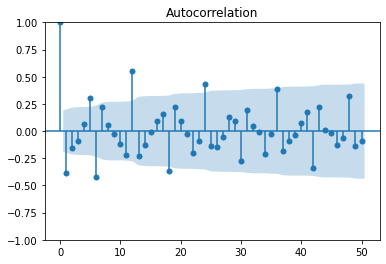

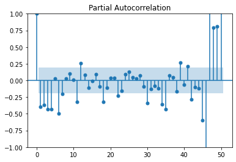

```python
plot_acf(y_dif1.dropna(), lags=50)
plot_pacf(y_dif1.dropna(), lags=50)
plt.savefig('p9_figures/Corelograme_d-autocorelation_simple_et_partiel_difference1.jpg')
plt.show()
```

Comme on peut le voir, il y a des pics significatifs dans le graphique ACF au décalage 6, 12 ,18... (composante saisonnière semestrielle). Dans le graphique PACF, les délais sont plus lents à se désintégrer autour de 22, 32, ainsi que des pics négatifs significatifs.

```python
#on diferencie a l ordre 12 pour eliminer la saisonalité
y_dif3 =y_dif1.diff(12)
```

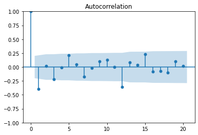

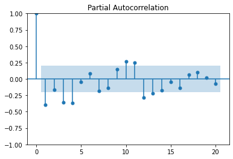

```python
plot_acf(y_dif3.dropna())
plot_pacf(y_dif3.dropna())
plt.savefig('p9_figures/Corelograme_d-autocorelation_simple_et_partiel_difference1_12.jpg')
plt.show()
```

autocorelation simples et partielle sanullent a partir du rang p+1 sur la base du corelograme cest une diference representant un pic significatif au retard 1 et retard 12 dans le corelograme autocorelation et une decroisance sinusuedale amortie qui va s'annuler dans le correlograme d autocorelation donc on peut suposer q'on est en presence d un phenoméne ARMA

## Estimation et validation des modèles1 SARIMA

Nous allons donc créer notre premier modèle SARIMA avec les paramètres estimés ci-dessus. Nous testerons la blancheur des résidus grâce au test de JUNG_BOX

```python
s_train=cons_train.copy()
s_test=cons_test.copy()
```

```python
s_train
```

| mois | Consommation_corg1 |
| --- | --- |
| 2012-01-01 | 42428.655018 |
| 2012-02-01 | 44334.279468 |
| 2012-03-01 | 42199.740492 |
| 2012-04-01 | 37779.436029 |
| 2012-05-01 | 39669.271314 |
| ... | ... |
| 2018-08-01 | 38734.207196 |
| 2018-09-01 | 41344.083053 |
| 2018-10-01 | 39546.174218 |
| 2018-11-01 | 38700.500577 |
| 2018-12-01 | 38478.891691 |

84 rows × 1 columns

```python
from statsmodels.tsa.statespace.sarimax import *
from statsmodels.stats.diagnostic import acorr_ljungbox

model0 = SARIMAX(np.asarray(s_train["Consommation_corg1"]), order=(1,1,1), seasonal_order=(1,1,1,12))
results0 = model0.fit()
print(results0.summary())

#test de blancheur sur les residues
print('Retard : p-value')
for elt in [6, 12, 18, 24, 30, 36]:
    print('{} : {}'.format(elt, acorr_ljungbox(results0.resid, lags=elt).mean()))
```

```
                                     SARIMAX Results
==========================================================================================
Dep. Variable:                                  y   No. Observations:                   84
Model:             SARIMAX(1, 1, 1)x(1, 1, 1, 12)   Log Likelihood                -644.839
Date:                            Thu, 07 Jul 2022   AIC                           1299.678
Time:                                    19:12:23   BIC                           1310.991
Sample:                                         0   HQIC                          1304.177
                                             - 84
Covariance Type:                              opg
==============================================================================
                 coef    std err          z      P>|z|      [0.025      0.975]
------------------------------------------------------------------------------
ar.L1          0.3851      0.146      2.637      0.008       0.099       0.671
ma.L1         -0.5442      0.118     -4.601      0.000      -0.776      -0.312
ar.S.L12      -0.7080    558.606     -0.001      0.999   -1095.555    1094.139
ma.S.L12       0.7080    558.633      0.001      0.999   -1094.193    1095.609
sigma2      3.203e+06   4.19e+05      7.647      0.000    2.38e+06    4.02e+06
===================================================================================
Ljung-Box (L1) (Q):                   5.77   Jarque-Bera (JB):                 1.52
Prob(Q):                              0.02   Prob(JB):                         0.47
Heteroskedasticity (H):               1.18   Skew:                             0.28
Prob(H) (two-sided):                  0.70   Kurtosis:                         3.44
===================================================================================

Warnings:
[1] Covariance matrix calculated using the outer product of gradients (complex-step).
Retard : p-value
6 : lb_stat      1.415924
lb_pvalue    0.759581
dtype: float64
12 : lb_stat      4.360298
lb_pvalue    0.775777
dtype: float64
18 : lb_stat      12.844748
lb_pvalue     0.522819
dtype: float64
24 : lb_stat      17.308334
lb_pvalue     0.416067
dtype: float64
30 : lb_stat      20.072889
lb_pvalue     0.391080
dtype: float64
36 : lb_stat      22.027058
lb_pvalue     0.417585
dtype: float64
```

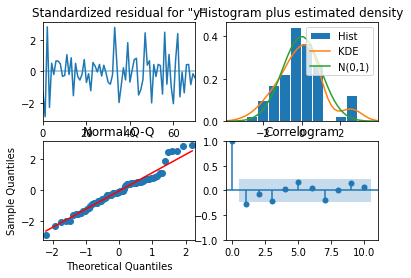

```python
results0.plot_diagnostics()
plt.savefig('p9_figures/normalité_des_residus_model0.jpg')
plt.show()
```

```python
shapiro(results0.resid)
```

```
ShapiroResult(statistic=0.47012341022491455, pvalue=7.086027762010037e-16)
```

on va utiliser le test Test de Jarque-Beraqui ne prend pas en compte les premiers residues qui divergent légèrement d'un schéma gaussien

```python
#Test de Jarque-Bera
results0.test_normality("jarquebera")[0][1]
```

```
0.46795658962724085
```

le test est pas significatif don on ne rejet pas l'hypothese de la normalité des residues

```python
from statsmodels.tsa.statespace.sarimax import *
from statsmodels.stats.diagnostic import acorr_ljungbox

model1 = SARIMAX(np.asarray(s_train["Consommation_corg1"]), order=(1,1,1), seasonal_order=(0,1,0,12))
results1 = model1.fit()
print(results1.summary())

#print('Retard : p-value')
for elt in [6, 12, 18, 24, 30, 36]:
    print('{} : {}'.format(elt, acorr_ljungbox(results1.resid, lags=elt).mean()))
```

```
                                      SARIMAX Results
===========================================================================================
Dep. Variable:                                   y   No. Observations:                   84
Model:             SARIMAX(1, 1, 1)x(0, 1, [], 12)   Log Likelihood                -643.455
Date:                             Thu, 07 Jul 2022   AIC                           1292.910
Time:                                     19:16:16   BIC                           1299.698
Sample:                                          0   HQIC                          1295.610
                                              - 84
Covariance Type:                               opg
==============================================================================
                 coef    std err          z      P>|z|      [0.025      0.975]
------------------------------------------------------------------------------
ar.L1          0.3721      0.202      1.841      0.066      -0.024       0.768
ma.L1         -0.5135      0.166     -3.089      0.002      -0.839      -0.188
sigma2      4.224e+06   6.52e+05      6.483      0.000    2.95e+06     5.5e+06
===================================================================================
Ljung-Box (L1) (Q):                   6.19   Jarque-Bera (JB):                 1.81
Prob(Q):                              0.01   Prob(JB):                         0.40
Heteroskedasticity (H):               1.19   Skew:                             0.32
Prob(H) (two-sided):                  0.67   Kurtosis:                         3.46
===================================================================================

Warnings:
[1] Covariance matrix calculated using the outer product of gradients (complex-step).
6 : lb_stat      1.371286
lb_pvalue    0.772174
dtype: float64
12 : lb_stat      4.334899
lb_pvalue    0.783224
dtype: float64
18 : lb_stat      12.898300
lb_pvalue     0.527459
dtype: float64
24 : lb_stat      17.397453
lb_pvalue     0.418589
dtype: float64
30 : lb_stat      20.181180
lb_pvalue     0.391573
dtype: float64
36 : lb_stat      22.148269
lb_pvalue     0.416470
dtype: float64
```

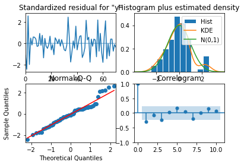

```python
results1.plot_diagnostics()
plt.savefig('p9_figures/normalité_des_residus_model1.jpg')
plt.show()
```

```python
shapiro(results1.resid)
```

```
ShapiroResult(statistic=0.46725624799728394, pvalue=6.4362862582258e-16)
```

```python
#Test de Jarque-Bera
results1.test_normality("jarquebera")[0][1]
```

```
0.40462704569811303
```

le test n est pas significatif don on ne rejet pas l'hypothese de la normalité des residues

## MODEL2

```python
from statsmodels.tsa.statespace.sarimax import *
from statsmodels.stats.diagnostic import acorr_ljungbox

model2 = SARIMAX(np.asarray(s_train["Consommation_corg1"]), order=(0,1,1), seasonal_order=(0,1,0,12))
results2 = model2.fit()
print(results2.summary())

#print('Retard : p-value')
for elt in [6, 12, 18, 24, 30, 36]:
    print('{} : {}'.format(elt, acorr_ljungbox(results2.resid, lags=elt).mean()))
```

```
                                      SARIMAX Results
===========================================================================================
Dep. Variable:                                   y   No. Observations:                   84
Model:             SARIMAX(0, 1, 1)x(0, 1, [], 12)   Log Likelihood                -643.499
Date:                             Thu, 07 Jul 2022   AIC                           1290.998
Time:                                     19:32:04   BIC                           1295.524
Sample:                                          0   HQIC                          1292.798
                                              - 84
Covariance Type:                               opg
==============================================================================
                 coef    std err          z      P>|z|      [0.025      0.975]
------------------------------------------------------------------------------
ma.L1         -0.1449      0.050     -2.870      0.004      -0.244      -0.046
sigma2      4.267e+06   6.38e+05      6.691      0.000    3.02e+06    5.52e+06
===================================================================================
Ljung-Box (L1) (Q):                   4.64   Jarque-Bera (JB):                 5.29
Prob(Q):                              0.03   Prob(JB):                         0.07
Heteroskedasticity (H):               1.31   Skew:                             0.57
Prob(H) (two-sided):                  0.51   Kurtosis:                         3.70
===================================================================================

Warnings:
[1] Covariance matrix calculated using the outer product of gradients (complex-step).
6 : lb_stat      1.576410
lb_pvalue    0.735775
dtype: float64
12 : lb_stat      4.675704
lb_pvalue    0.755824
dtype: float64
18 : lb_stat      13.302670
lb_pvalue     0.508447
dtype: float64
24 : lb_stat      17.829839
lb_pvalue     0.401953
dtype: float64
30 : lb_stat      20.626135
lb_pvalue     0.374307
dtype: float64
36 : lb_stat      22.612879
lb_pvalue     0.397481
dtype: float64
```

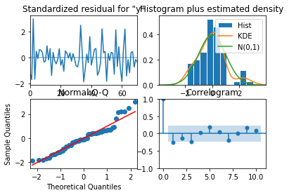

```python
results2.plot_diagnostics()
plt.savefig('p9_figures/normalité_des_residus_model2.jpg')
plt.show()
```

```python
shapiro(results2.resid)
```

```
ShapiroResult(statistic=0.4701400399208069, pvalue=7.089999817137067e-16)
```

```python
#Test de Jarque-Bera
results2.test_normality("jarquebera")[0][1]
```

```
0.071153098748574
```

# SARIMA optimal

Construisons le modèle SARIMA sur la serie train en utilisant la fonction auto_arima() de pmdarima. Pour ce faire, vous devez définir season=True, définir la fréquence m=12 pour les séries mensuelles et appliquer D=1.

```python
import pmdarima as pm
```

```python
#from statsmodels.tsa.arima_model import ARIMA

#import pmdarima as pm

# Seasonal - fit stepwise auto-ARIMA
smodel3 = pm.auto_arima(s_train, start_p=1, start_q=1,
                         test='adf',m=12,
                         max_p=3, max_q=3,

                         start_P=0, seasonal=True,
                         d=None, D=1, trace=True,
                         error_action='ignore',
                         suppress_warnings=True,
                         stepwise=True)

smodel3.summary()
```

```
Performing stepwise search to minimize aic
 ARIMA(1,1,1)(0,1,1)[12]             : AIC=1276.482, Time=0.44 sec
 ARIMA(0,1,0)(0,1,0)[12]             : AIC=1294.855, Time=0.05 sec
 ARIMA(1,1,0)(1,1,0)[12]             : AIC=1283.706, Time=0.14 sec
 ARIMA(0,1,1)(0,1,1)[12]             : AIC=1282.488, Time=0.16 sec
 ARIMA(1,1,1)(0,1,0)[12]             : AIC=1292.910, Time=0.33 sec
 ARIMA(1,1,1)(1,1,1)[12]             : AIC=1299.678, Time=0.39 sec
 ARIMA(1,1,1)(0,1,2)[12]             : AIC=1277.349, Time=0.89 sec
 ARIMA(1,1,1)(1,1,0)[12]             : AIC=1278.325, Time=0.42 sec
 ARIMA(1,1,1)(1,1,2)[12]             : AIC=inf, Time=1.53 sec
 ARIMA(1,1,0)(0,1,1)[12]             : AIC=1282.043, Time=0.14 sec
 ARIMA(2,1,1)(0,1,1)[12]             : AIC=1278.969, Time=0.42 sec
 ARIMA(1,1,2)(0,1,1)[12]             : AIC=1286.864, Time=0.39 sec
 ARIMA(0,1,0)(0,1,1)[12]             : AIC=1289.557, Time=0.08 sec
 ARIMA(0,1,2)(0,1,1)[12]             : AIC=1284.624, Time=0.24 sec
 ARIMA(2,1,0)(0,1,1)[12]             : AIC=1282.435, Time=0.15 sec
 ARIMA(2,1,2)(0,1,1)[12]             : AIC=1279.115, Time=0.63 sec
 ARIMA(1,1,1)(0,1,1)[12] intercept   : AIC=1278.386, Time=0.45 sec

Best model:  ARIMA(1,1,1)(0,1,1)[12]
Total fit time: 6.956 seconds
```

SARIMAX Results

| Dep. Variable: | y | No. Observations: | 84 |
| --- | --- | --- | --- |
| Model: | SARIMAX(1, 1, 1)x(0, 1, 1, 12) | Log Likelihood | -634.241 |
| Date: | Thu, 07 Jul 2022 | AIC | 1276.482 |
| Time: | 18:56:48 | BIC | 1285.532 |
| Sample: | 0 | HQIC | 1280.081 |
|  | - 84 |  |  |
| Covariance Type: | opg |  |  |

|  | coef | std err | z | P>\|z\| | [0.025 | 0.975] |
| --- | --- | --- | --- | --- | --- | --- |
| ar.L1 | -0.7977 | 0.126 | -6.351 | 0.000 | -1.044 | -0.552 |
| ma.L1 | 0.6500 | 0.156 | 4.178 | 0.000 | 0.345 | 0.955 |
| ma.S.L12 | -0.2233 | 0.041 | -5.445 | 0.000 | -0.304 | -0.143 |
| sigma2 | 3.203e+06 | 4.62e+05 | 6.939 | 0.000 | 2.3e+06 | 4.11e+06 |

| Ljung-Box (L1) (Q): | 2.15 | Jarque-Bera (JB): | 2.57 |
| --- | --- | --- | --- |
| Prob(Q): | 0.14 | Prob(JB): | 0.28 |
| Heteroskedasticity (H): | 2.00 | Skew: | 0.31 |
| Prob(H) (two-sided): | 0.10 | Kurtosis: | 3.70 |

Warnings:  
[1] Covariance matrix calculated using the outer product of gradients (complex-step).

le model choisi est le model ARIMA(1,1,1)(0,1,1)[12]

```python
model3 = SARIMAX(np.asarray(s_train["Consommation_corg1"]), order=(1,1,1), seasonal_order=(0,1,1,12))
results3 = model3.fit()
print(results3.summary())
print('Retard : p-value')
for elt in [6, 12, 18, 24, 30, 36]:
    print('{} : {}'.format(elt, acorr_ljungbox(results3.resid, lags=elt).mean()))
```

```
                                     SARIMAX Results
==========================================================================================
Dep. Variable:                                  y   No. Observations:                   84
Model:             SARIMAX(1, 1, 1)x(0, 1, 1, 12)   Log Likelihood                -634.241
Date:                            Thu, 07 Jul 2022   AIC                           1276.482
Time:                                    18:56:49   BIC                           1285.532
Sample:                                         0   HQIC                          1280.081
                                             - 84
Covariance Type:                              opg
==============================================================================
                 coef    std err          z      P>|z|      [0.025      0.975]
------------------------------------------------------------------------------
ar.L1         -0.7977      0.126     -6.351      0.000      -1.044      -0.552
ma.L1          0.6500      0.156      4.178      0.000       0.345       0.955
ma.S.L12      -0.2233      0.041     -5.445      0.000      -0.304      -0.143
sigma2      3.203e+06   4.62e+05      6.939      0.000     2.3e+06    4.11e+06
===================================================================================
Ljung-Box (L1) (Q):                   2.15   Jarque-Bera (JB):                 2.57
Prob(Q):                              0.14   Prob(JB):                         0.28
Heteroskedasticity (H):               2.00   Skew:                             0.31
Prob(H) (two-sided):                  0.10   Kurtosis:                         3.70
===================================================================================

Warnings:
[1] Covariance matrix calculated using the outer product of gradients (complex-step).
Retard : p-value
6 : lb_stat      1.801166
lb_pvalue    0.665040
dtype: float64
12 : lb_stat      4.270485
lb_pvalue    0.715927
dtype: float64
18 : lb_stat      10.151397
lb_pvalue     0.521580
dtype: float64
24 : lb_stat      13.215083
lb_pvalue     0.493048
dtype: float64
30 : lb_stat      15.141654
lb_pvalue     0.536798
dtype: float64
36 : lb_stat      16.537049
lb_pvalue     0.596844
dtype: float64
```

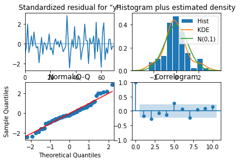

```python
results3.plot_diagnostics()
plt.savefig('p9_figures/normalité_des_residus_model3.jpg')
plt.show()
```

# shapiro(results1.resid)

```python
shapiro(results1.resid)
```

```
ShapiroResult(statistic=0.46725624799728394, pvalue=6.4362862582258e-16)
```

```python
#Test de Jarque-Bera
results3.test_normality("jarquebera")[0][1]
```

```
0.2771802880260108
```

# PREVISION avec lemodel 3 optimal

```python
pred_uc = results3.get_forecast(steps=12,alpha=0.05)
pred_ci = pred_uc.conf_int()
```

```python
pred_uc
pred_ci
```

```
array([[36177.49467338, 43192.92177212],
       [35151.32902964, 44368.95118155],
       [33220.84013639, 44678.71894577],
       [31324.93489483, 44327.21423267],
       [30512.10911627, 45126.46836882],
       [32117.98173991, 48013.74719821],
       [29494.7887753 , 46701.46943549],
       [27939.11307216, 46269.88546783],
       [29908.58468255, 49368.87444933],
       [27766.93456971, 48241.23184251],
       [26532.71693622, 48013.74317126],
       [25902.13380856, 48313.69832257]])
```

```python
pred=pd.DataFrame(pred_ci)
```

```python
pred['prediction']=pred.mean(axis=1)
```

```python
s_res=s_test.reset_index()
```

```python
s_test
```

| mois | Consommation_corg1 |
| --- | --- |
| 2019-01-01 | 41178.286266 |
| 2019-02-01 | 44910.825692 |
| 2019-03-01 | 39796.498723 |
| 2019-04-01 | 39197.549279 |
| 2019-05-01 | 38386.864738 |
| 2019-06-01 | 39707.452832 |
| 2019-07-01 | 41038.894289 |
| 2019-08-01 | 38039.125782 |
| 2019-09-01 | 41636.117638 |
| 2019-10-01 | 38145.058462 |
| 2019-11-01 | 38965.904599 |
| 2019-12-01 | 37610.153460 |

```python
con_pred=pd.concat([s_res, pred], axis=1)
```

```python
#con_pred
```

```python
con_pred["mois"]=pd.to_datetime(con_pred["mois"])
con_pred=con_pred
```

```python
cons_res=cons_s.reset_index()
```

```python
s_mrg=cons_res.merge(con_pred, how='left')
s_mrg=s_mrg.set_index('mois')
s_mrg
```

| mois | Consommation_corg1 | 0 | 1 | prediction |
| --- | --- | --- | --- | --- |
| 2012-01-01 | 42428.655018 | NaN | NaN | NaN |
| 2012-02-01 | 44334.279468 | NaN | NaN | NaN |
| 2012-03-01 | 42199.740492 | NaN | NaN | NaN |
| 2012-04-01 | 37779.436029 | NaN | NaN | NaN |
| 2012-05-01 | 39669.271314 | NaN | NaN | NaN |
| ... | ... | ... | ... | ... |
| 2020-08-01 | 36246.504267 | NaN | NaN | NaN |
| 2020-09-01 | 39508.438570 | NaN | NaN | NaN |
| 2020-10-01 | 39104.359207 | NaN | NaN | NaN |
| 2020-11-01 | 37581.758582 | NaN | NaN | NaN |
| 2020-12-01 | 37806.122092 | NaN | NaN | NaN |

108 rows × 4 columns

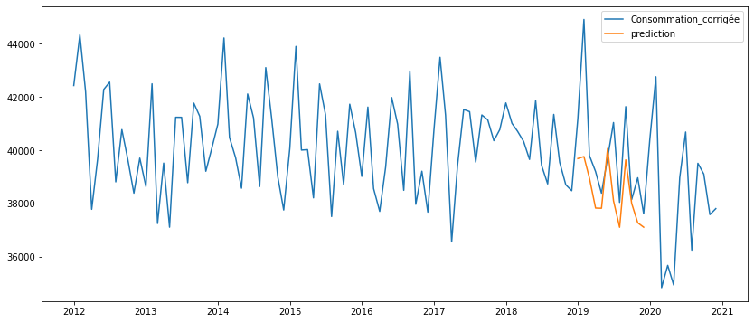

```python
plt.figure(figsize=(14,6))
#plt.plot(cons_s['Consommation_corg1'], label='Serie Corrigee sans dju')
plt.plot(s_mrg['Consommation_corg1'], label='Consommation_corrigée')
plt.plot(s_mrg['prediction'], label='prediction')
plt.savefig('p9_figures/prediction_SARIMA.jpg')
plt.legend()
```

```python
t_s=s_mrg.iloc[-24:-12,:1]
```

```python
p_s=s_mrg.iloc[-24:-12:,3:]
p_i=s_mrg.iloc[-24:-12:,1:3]
p_i
```

| mois | 0 | 1 |
| --- | --- | --- |
| 2019-01-01 | 36177.494673 | 43192.921772 |
| 2019-02-01 | 35151.329030 | 44368.951182 |
| 2019-03-01 | 33220.840136 | 44678.718946 |
| 2019-04-01 | 31324.934895 | 44327.214233 |
| 2019-05-01 | 30512.109116 | 45126.468369 |
| 2019-06-01 | 32117.981740 | 48013.747198 |
| 2019-07-01 | 29494.788775 | 46701.469435 |
| 2019-08-01 | 27939.113072 | 46269.885468 |
| 2019-09-01 | 29908.584683 | 49368.874449 |
| 2019-10-01 | 27766.934570 | 48241.231843 |
| 2019-11-01 | 26532.716936 | 48013.743171 |
| 2019-12-01 | 25902.133809 | 48313.698323 |

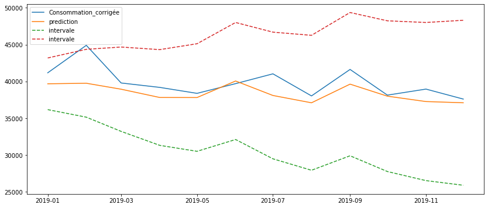

```python
plt.figure(figsize=(14,6))
#plt.plot(cons_s['Consommation_corg1'], label='Serie Corrigee sans dju')
plt.plot(t_s, label='Consommation_corrigée')
plt.plot(p_s, label='prediction')
plt.plot(p_i,linestyle='--', label='intervale')
plt.savefig('p9_figures/prediction_SARIMA_test.jpg')
plt.legend()
```

## evaluation métrique du model Sarima

```python
from sklearn.metrics import mean_absolute_error,mean_squared_error
print(f'Mean Absolute Error = {mean_absolute_error(t_s,p_s)}')
print(f'Mean Squared Error = {mean_squared_error(t_s,p_s)}')
```

```
Mean Absolute Error = 1499.717676893689
Mean Squared Error = 4037980.9137362097
```